# Предсказание температуры сплава

# Содержание

- 1 Подготовка и анализ
  - 1.1 Вспомогательный блок
  - 1.2 data_arc_new
    - 1.2.1 Первичный осмотр
    - 1.2.2 Выбросы
    - 1.2.3 Распределение значений
    - 1.2.4 Корреляция значений
    - 1.2.5 Вывод
  - 1.3 data_bulk_new
    - 1.3.1 Первичный осмотр
    - 1.3.2 Выбросы
    - 1.3.3 Распределение значений
    - 1.3.4 Корреляция значений
    - 1.3.5 Вывод
  - 1.4 data_bulk_time_new
    - 1.4.1 Первичный осмотр
    - 1.4.2 Вывод
  - 1.5 data_gas_new
    - 1.5.1 Первичный осмотр
    - 1.5.2 Выбросы
    - 1.5.3 Распределение значений
    - 1.5.4 Вывод
  - 1.6 data_temp_new
    - 1.6.1 Первичный осмотр
    - 1.6.2 Выбросы
    - 1.6.3 Распределение значений
    - 1.6.4 Вывод
  - 1.7 data_wire_new
    - 1.7.1 Первичный осмотр
    - 1.7.2 Выбросы
    - 1.7.3 Распределение значений
    - 1.7.4 Вывод
  - 1.8 data_wire_time_new
    - 1.8.1 Вывод
  - 1.9 Сравнение временных интервалов
  - 1.10 Вывод
- 2 Предобработка
  - 2.1 data_arc_new
    - 2.1.1 Агрегирование
  - 2.2 data_bulk_new
  - 2.3 data_gas_new
  - 2.4 data_temp_new
    - 2.4.1 Оптимальная температура плавки
    - 2.4.2 Агрегирование
  - 2.5 data_wire_new
  - 2.6 Объединение
    - 2.6.1 Корреляция
- 3 Подготовка признаков
  - 3.1 Вспомогательный блок
  - 3.2 Разделение на выбороки
  - 3.3 Изучение и обработка выборок
    - 3.3.1 train
      - 3.3.1.1 температура
      - 3.3.1.2 газ
      - 3.3.1.3 акт_мощ(median)
      - 3.3.1.4 дуга_сек(median)
      - 3.3.1.5 Вывод
  - 3.4 Обучающий и целевой
- 4 Обучение
  - 4.1 LinearRegression
  - 4.2 LightGBM
  - 4.3 CatBoostRegressor
  - 4.4 Тестирование
  - 4.5 Анализ важности факторов
- 5 Вывод
- 6 Отчёт

**Задача**:  
Построить модель, которая предскажет температуру стали.

**Описание этапа обработки**

**Описание данных**  
Данные состоят из файлов, полученных из разных источников:

- data_arc_new.csv — данные об электродах;
- data_bulk_new.csv — данные о подаче сыпучих материалов (объём);
- data_bulk_time_new.csv — данные о подаче сыпучих материалов (время);
- data_gas_new.csv — данные о продувке сплава газом;
- data_temp_new.csv — результаты измерения температуры;
- data_wire_new.csv — данные о проволочных материалах (объём);
- data_wire_time_new.csv — данные о проволочных материалах (время).

Во всех файлах столбец `key` содержит номер партии. В файлах может быть несколько строк с одинаковым значением `key`: они соответствуют разным итерациям обработки.

**План работы**

1. Подготовка и анализ;
2. Предобработка;
3. Подготовка признаков;
4. Обучение;
5. Выводы

## Подготовка и анализ

Произведём импорт основных библиотек и модулей

```python
import pandas as pd
from IPython.display import display
import seaborn as sns
import matplotlib.pyplot as plt

from sklearn.metrics import mean_absolute_error, make_scorer
from sklearn.model_selection import (train_test_split,
                                     cross_val_score,
                                     GridSearchCV)
from sklearn.linear_model import LinearRegression
from catboost import CatBoostRegressor
import lightgbm as lgb
```

Определим функцию для загрузки файлов

```python
def download_file(name):
    """
    Функция проходит по возможным директориям
    в попытке найти файл, используя конструкции
    try, except и итераторы. Возвращая прочтённый
    файл или ошибку, если файл не найден.
    """
    def read(name):
        next_step = next(step)
        print(f'Пробую найти файл в {next_step}: {directory[next_step]}.')
        return pd.read_csv(directory[next_step] + name + '.csv', index_col=[0], sep=',')

    def error(err):
        print(f'Возникла ошибка: {err}\n')

    print('\nИщем файл для имени:', name)
    directory = {'windows':'data/', 'linux':'/datasets/', 'Internet':'https:..'}
    step = iter(directory)

    try:
        data = read(name)
    except FileNotFoundError as err1:
        try:
            data = read(name)
        except FileNotFoundError as err2:
            try:
                data = read(name)
            except Exception as err3:
                error(err1)
                error(err2)
                return error(err3)

    print('Успех!')
    return data
```

**Получим файлы**

```python
data_arc_new = download_file('data_arc_new')
data_bulk_new = download_file('data_bulk_new')
data_bulk_time_new = download_file('data_bulk_time_new')
data_gas_new = download_file('data_gas_new')
data_temp_new = download_file('data_temp_new')
data_wire_new = download_file('data_wire_new')
data_wire_time_new = download_file('data_wire_time_new')
```

```
Ищем файл для имени: data_arc_new
Пробую найти файл в windows: data/.
Успех!

Ищем файл для имени: data_bulk_new
Пробую найти файл в windows: data/.
Успех!

Ищем файл для имени: data_bulk_time_new
Пробую найти файл в windows: data/.
Успех!

Ищем файл для имени: data_gas_new
Пробую найти файл в windows: data/.
Успех!

Ищем файл для имени: data_temp_new
Пробую найти файл в windows: data/.
Успех!

Ищем файл для имени: data_wire_new
Пробую найти файл в windows: data/.
Успех!

Ищем файл для имени: data_wire_time_new
Пробую найти файл в windows: data/.
Успех!
```

*Проведём изучение каждого из них*

### Вспомогательный блок

Подготовим блок функций для анализа, определим функцию.

```python
def head_tail_info_desc(name):
    print(f'\n.head()')
    display(name.head())

    print(f'\n.tail()')
    display(name.tail())

    print(f'\n.info()')
    display(name.info())

    print(f'\n.describe()')
    display(name.describe())
```

### data_arc_new

#### Первичный осмотр

```python
head_tail_info_desc(data_arc_new);
```

```
.head()
```

| key | Начало нагрева дугой | Конец нагрева дугой | Активная мощность | Реактивная мощность |
| --- | --- | --- | --- | --- |
| 1 | 2019-05-03 11:02:14 | 2019-05-03 11:06:02 | 0.305130 | 0.211253 |
| 1 | 2019-05-03 11:07:28 | 2019-05-03 11:10:33 | 0.765658 | 0.477438 |
| 1 | 2019-05-03 11:11:44 | 2019-05-03 11:14:36 | 0.580313 | 0.430460 |
| 1 | 2019-05-03 11:18:14 | 2019-05-03 11:24:19 | 0.518496 | 0.379979 |
| 1 | 2019-05-03 11:26:09 | 2019-05-03 11:28:37 | 0.867133 | 0.643691 |

```
.tail()
```

| key | Начало нагрева дугой | Конец нагрева дугой | Активная мощность | Реактивная мощность |
| --- | --- | --- | --- | --- |
| 3241 | 2019-09-06 16:49:05 | 2019-09-06 16:51:42 | 0.439735 | 0.299579 |
| 3241 | 2019-09-06 16:55:11 | 2019-09-06 16:58:11 | 0.646498 | 0.458240 |
| 3241 | 2019-09-06 17:06:48 | 2019-09-06 17:09:52 | 1.039726 | 0.769302 |
| 3241 | 2019-09-06 17:21:58 | 2019-09-06 17:22:55 | 0.530267 | 0.361543 |
| 3241 | 2019-09-06 17:24:54 | 2019-09-06 17:26:15 | 0.389057 | 0.251347 |

```
.info()
<class 'pandas.core.frame.DataFrame'>
Index: 14876 entries, 1 to 3241
Data columns (total 4 columns):
 #   Column                Non-Null Count  Dtype
---  ------                --------------  -----
 0   Начало нагрева дугой  14876 non-null  object
 1   Конец нагрева дугой   14876 non-null  object
 2   Активная мощность     14876 non-null  float64
 3   Реактивная мощность   14876 non-null  float64
dtypes: float64(2), object(2)
memory usage: 581.1+ KB
```

```
None
```

```
.describe()
```

|  | Активная мощность | Реактивная мощность |
| --- | --- | --- |
| count | 14876.000000 | 14876.000000 |
| mean | 0.662752 | 0.438986 |
| std | 0.258885 | 5.873485 |
| min | 0.223120 | -715.479924 |
| 25% | 0.467115 | 0.337175 |
| 50% | 0.599587 | 0.441639 |
| 75% | 0.830070 | 0.608201 |
| max | 1.463773 | 1.270284 |

Изучим сколько партий есть в наборе данных. Для этого поместим те, которых нет(в промежутке от 1 до 3241) в отдельный список.

```python
mis_val = []
for i in range(data_arc_new.index.unique().values.max()):
    if i+1 not in data_arc_new.index.unique().values:
        mis_val.append(i+1)

print(mis_val)
```

```
[41, 42, 195, 279, 355, 382, 506, 529, 540, 607, 683, 710, 766, 1133, 1300, 1437, 2031, 2103, 2278, 2356, 2373, 2446, 2469, 2491, 2683, 3200, 3207]
```

Оценим сколько циклов бывает

```python
data_arc_new.index.value_counts().describe()
```

```
count    3214.000000
mean        4.628500
std         1.608647
min         1.000000
25%         4.000000
50%         4.000000
75%         6.000000
max        16.000000
Name: count, dtype: float64
```

*Данные представлены циклами от 1 до 16*

Проведём простейшую предобработку.

```python
data_arc_new['Начало нагрева дугой'] = pd.to_datetime(data_arc_new['Начало нагрева дугой'], format='%Y-%m-%d %H:%M:%S')
data_arc_new['Конец нагрева дугой'] = pd.to_datetime(data_arc_new['Конец нагрева дугой'], format='%Y-%m-%d %H:%M:%S')
```

#### Выбросы

Изучим выбросы в столбцах:

- Активная мощность;
- Реактивная мощность.

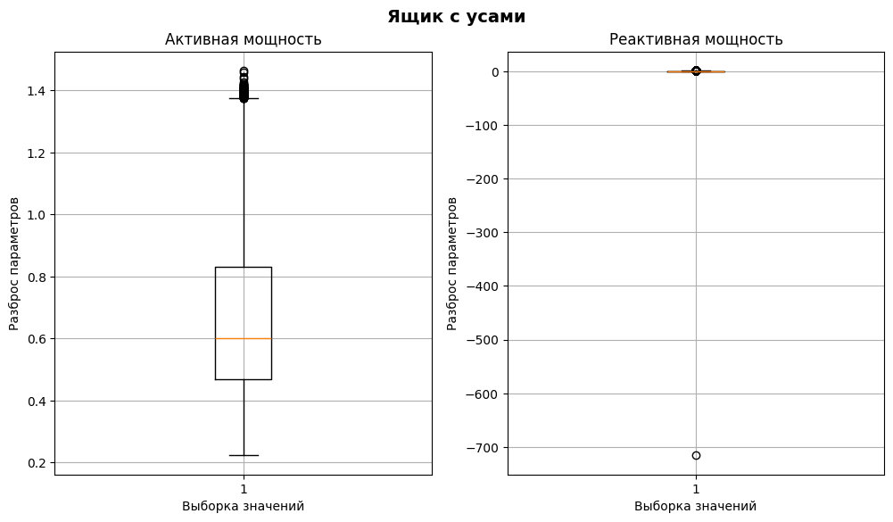

```python
fig, ax = plt.subplots(1, 2, figsize = (12, 6))
fig.suptitle('Ящик с усами', fontsize=14, fontweight='bold')
fig.subplots_adjust(top=0.9)

moustache_dan = {}
param = {'Активная мощность':None, 'Реактивная мощность':None}
count = 0
for key, val in param.items():
    b = ax[count].boxplot(data_arc_new[key])
    #Выделение крайних усов боксплота
    moustache_dan[key] = [item.get_ydata()[1] for item in b['whiskers']]
    ax[count].grid()
    ax[count].set_title(key)
    ax[count].set_xlabel('Выборка значений')
    ax[count].set_ylabel('Разброс параметров')
    count += 1
```

Изучим границы усов

```python
print(moustache_dan)
```

```
{'Активная мощность': [0.22312, 1.373621], 'Реактивная мощность': [0.153777, 1.014739]}
```

*На первом графике параметры мощности представлены достаточно близко друг другу. Так как это производство, то с обрезанием по усам значений надо быть аккуратным, поэтому параметры граничных значений можно попробовать узнать у заказчика. Второй график надо изучить подробнее, чтобы определить по каким границам строить ящик с усами.*

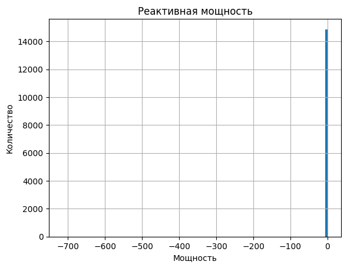

```python
data_arc_new.hist(column='Реактивная мощность',bins=100)
plt.xlabel('Мощность')
plt.ylabel('Количество');
```

```python
data_arc_new.sort_values(by='Реактивная мощность').head(5)
```

| key | Начало нагрева дугой | Конец нагрева дугой | Активная мощность | Реактивная мощность |
| --- | --- | --- | --- | --- |
| 2116 | 2019-07-28 02:22:08 | 2019-07-28 02:23:57 | 0.705344 | -715.479924 |
| 152 | 2019-05-09 11:26:58 | 2019-05-09 11:29:41 | 0.228852 | 0.153777 |
| 711 | 2019-05-31 07:16:01 | 2019-05-31 07:20:05 | 0.242989 | 0.153921 |
| 2567 | 2019-08-13 05:51:16 | 2019-08-13 05:52:22 | 0.288314 | 0.155221 |
| 1336 | 2019-06-22 15:46:26 | 2019-06-22 15:47:50 | 0.244191 | 0.156525 |

*Других выбивающихся значений не обнаружено, ограничим выборку.*

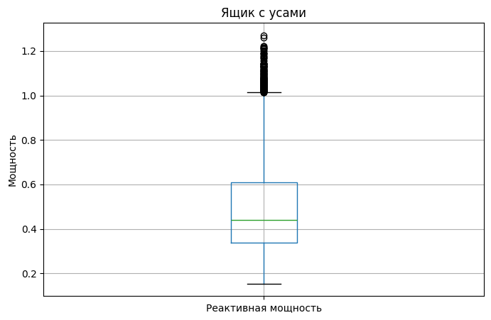

```python
b = data_arc_new.query('0 < `Реактивная мощность` < 1.28')\
    .boxplot(column = 'Реактивная мощность', figsize=(8,5), return_type='dict')

plt.ylabel('Мощность')
plt.title('Ящик с усами');

moustache_dan['Реактивная мощность'] = [item.get_ydata()[1] for item in b['whiskers']]
```

Перепроверим параметры

```python
print(moustache_dan)
```

```
{'Активная мощность': [0.22312, 1.373621], 'Реактивная мощность': [0.153777, 1.014739]}
```

```python
ans = data_arc_new.loc[(data_arc_new['Активная мощность'] > moustache_dan["Активная мощность"][0]) &
                 (data_arc_new['Активная мощность'] < moustache_dan["Активная мощность"][1]) &
                 (data_arc_new['Реактивная мощность'] > moustache_dan["Реактивная мощность"][0]) &
                 (data_arc_new['Реактивная мощность'] < moustache_dan["Реактивная мощность"][1])]

print('Процентное количество выбросов:', round(1 - ans.shape[0]/data_arc_new.shape[0],2))
```

```
Процентное количество выбросов: 0.02
```

*Достаточно малое количество выбросов говорит о возможности удаления*

#### Распределение значений

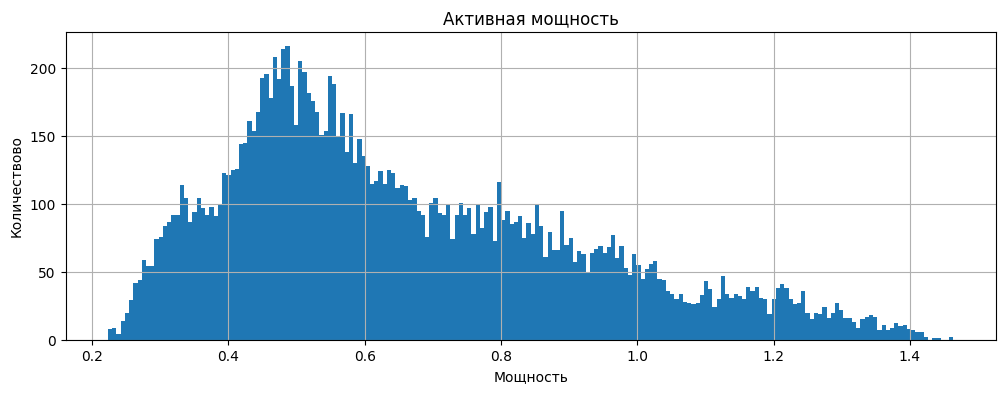

```python
data_arc_new.hist(column='Активная мощность', bins=200, figsize=(12,4))
plt.xlabel('Мощность')
plt.ylabel('Количествово');
```

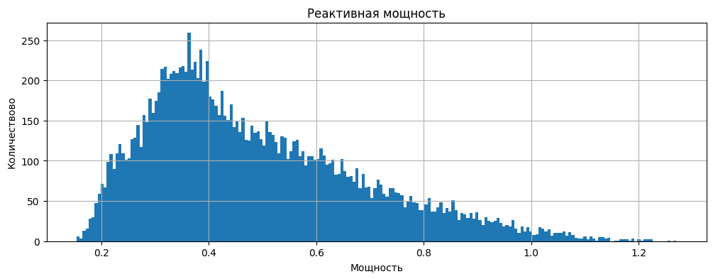

```python
data_arc_new.query('0 < `Реактивная мощность` < 1.28')\
.hist(column='Реактивная мощность', bins=200, figsize=(12,4))
plt.xlabel('Мощность')
plt.ylabel('Количествово');
```

**Вывод**: распределение рассмотренных графиков смещено вправо.

#### Корреляция значений

```python
data_arc_new.corr()
```

|  | Начало нагрева дугой | Конец нагрева дугой | Активная мощность | Реактивная мощность |
| --- | --- | --- | --- | --- |
| Начало нагрева дугой | 1.000000 | 1.000000 | -0.010461 | -0.005437 |
| Конец нагрева дугой | 1.000000 | 1.000000 | -0.010461 | -0.005436 |
| Активная мощность | -0.010461 | -0.010461 | 1.000000 | 0.031164 |
| Реактивная мощность | -0.005437 | -0.005436 | 0.031164 | 1.000000 |

*На первый взгляд наблюдается её отсутствие, однако, если граничить выборку по выбросам, получим следующий результат.*

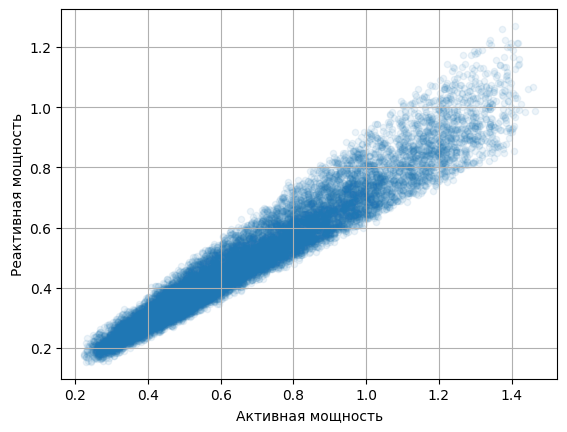

```python
data_arc_new.query('0 < `Реактивная мощность` < 1.28')\
.plot(x='Активная мощность', y='Реактивная мощность', kind='scatter', alpha=0.08, grid=True);
```

```python
data_arc_new.query('0 < `Реактивная мощность` < 1.28').corr()
```

|  | Начало нагрева дугой | Конец нагрева дугой | Активная мощность | Реактивная мощность |
| --- | --- | --- | --- | --- |
| Начало нагрева дугой | 1.000000 | 1.000000 | -0.010468 | -0.013353 |
| Конец нагрева дугой | 1.000000 | 1.000000 | -0.010468 | -0.013353 |
| Активная мощность | -0.010468 | -0.010468 | 1.000000 | 0.966373 |
| Реактивная мощность | -0.013353 | -0.013353 | 0.966373 | 1.000000 |

Данные параметры должны быть еще лучше и стремиться к 1, вероятно, что причиной являются погрешности измерений.

### data_bulk_new

#### Первичный осмотр

```python
head_tail_info_desc(data_bulk_new);
```

```
.head()
```

| key | Bulk 1 | Bulk 2 | Bulk 3 | Bulk 4 | Bulk 5 | Bulk 6 | Bulk 7 | Bulk 8 | Bulk 9 | Bulk 10 | Bulk 11 | Bulk 12 | Bulk 13 | Bulk 14 | Bulk 15 |
| --- | --- | --- | --- | --- | --- | --- | --- | --- | --- | --- | --- | --- | --- | --- | --- |
| 1 | NaN | NaN | NaN | 43.0 | NaN | NaN | NaN | NaN | NaN | NaN | NaN | 206.0 | NaN | 150.0 | 154.0 |
| 2 | NaN | NaN | NaN | 73.0 | NaN | NaN | NaN | NaN | NaN | NaN | NaN | 206.0 | NaN | 149.0 | 154.0 |
| 3 | NaN | NaN | NaN | 34.0 | NaN | NaN | NaN | NaN | NaN | NaN | NaN | 205.0 | NaN | 152.0 | 153.0 |
| 4 | NaN | NaN | NaN | 81.0 | NaN | NaN | NaN | NaN | NaN | NaN | NaN | 207.0 | NaN | 153.0 | 154.0 |
| 5 | NaN | NaN | NaN | 78.0 | NaN | NaN | NaN | NaN | NaN | NaN | NaN | 203.0 | NaN | 151.0 | 152.0 |

```
.tail()
```

| key | Bulk 1 | Bulk 2 | Bulk 3 | Bulk 4 | Bulk 5 | Bulk 6 | Bulk 7 | Bulk 8 | Bulk 9 | Bulk 10 | Bulk 11 | Bulk 12 | Bulk 13 | Bulk 14 | Bulk 15 |
| --- | --- | --- | --- | --- | --- | --- | --- | --- | --- | --- | --- | --- | --- | --- | --- |
| 3237 | NaN | NaN | 170.0 | NaN | NaN | NaN | NaN | NaN | NaN | NaN | NaN | 252.0 | NaN | 130.0 | 206.0 |
| 3238 | NaN | NaN | 126.0 | NaN | NaN | NaN | NaN | NaN | NaN | NaN | NaN | 254.0 | NaN | 108.0 | 106.0 |
| 3239 | NaN | NaN | NaN | NaN | NaN | 114.0 | NaN | NaN | NaN | NaN | NaN | 158.0 | NaN | 270.0 | 88.0 |
| 3240 | NaN | NaN | NaN | NaN | NaN | 26.0 | NaN | NaN | NaN | NaN | NaN | NaN | NaN | 192.0 | 54.0 |
| 3241 | NaN | NaN | NaN | NaN | NaN | NaN | NaN | NaN | NaN | NaN | NaN | NaN | NaN | 180.0 | 52.0 |

```
.info()
<class 'pandas.core.frame.DataFrame'>
Index: 3129 entries, 1 to 3241
Data columns (total 15 columns):
 #   Column   Non-Null Count  Dtype
---  ------   --------------  -----
 0   Bulk 1   252 non-null    float64
 1   Bulk 2   22 non-null     float64
 2   Bulk 3   1298 non-null   float64
 3   Bulk 4   1014 non-null   float64
 4   Bulk 5   77 non-null     float64
 5   Bulk 6   576 non-null    float64
 6   Bulk 7   25 non-null     float64
 7   Bulk 8   1 non-null      float64
 8   Bulk 9   19 non-null     float64
 9   Bulk 10  176 non-null    float64
 10  Bulk 11  177 non-null    float64
 11  Bulk 12  2450 non-null   float64
 12  Bulk 13  18 non-null     float64
 13  Bulk 14  2806 non-null   float64
 14  Bulk 15  2248 non-null   float64
dtypes: float64(15)
memory usage: 391.1 KB
```

```
None
```

```
.describe()
```

|  | Bulk 1 | Bulk 2 | Bulk 3 | Bulk 4 | Bulk 5 | Bulk 6 | Bulk 7 | Bulk 8 | Bulk 9 | Bulk 10 | Bulk 11 | Bulk 12 | Bulk 13 | Bulk 14 | Bulk 15 |
| --- | --- | --- | --- | --- | --- | --- | --- | --- | --- | --- | --- | --- | --- | --- | --- |
| count | 252.000000 | 22.000000 | 1298.000000 | 1014.000000 | 77.000000 | 576.000000 | 25.000000 | 1.0 | 19.000000 | 176.000000 | 177.000000 | 2450.000000 | 18.000000 | 2806.000000 | 2248.000000 |
| mean | 39.242063 | 253.045455 | 113.879045 | 104.394477 | 107.025974 | 118.925347 | 305.600000 | 49.0 | 76.315789 | 83.284091 | 76.819209 | 260.471020 | 181.111111 | 170.284747 | 160.513345 |
| std | 18.277654 | 21.180578 | 75.483494 | 48.184126 | 81.790646 | 72.057776 | 191.022904 | NaN | 21.720581 | 26.060347 | 59.655365 | 120.649269 | 46.088009 | 65.868652 | 51.765319 |
| min | 10.000000 | 228.000000 | 6.000000 | 12.000000 | 11.000000 | 17.000000 | 47.000000 | 49.0 | 63.000000 | 24.000000 | 8.000000 | 53.000000 | 151.000000 | 16.000000 | 1.000000 |
| 25% | 27.000000 | 242.000000 | 58.000000 | 72.000000 | 70.000000 | 69.750000 | 155.000000 | 49.0 | 66.000000 | 64.000000 | 25.000000 | 204.000000 | 153.250000 | 119.000000 | 105.000000 |
| 50% | 31.000000 | 251.500000 | 97.500000 | 102.000000 | 86.000000 | 100.000000 | 298.000000 | 49.0 | 68.000000 | 86.500000 | 64.000000 | 208.000000 | 155.500000 | 151.000000 | 160.000000 |
| 75% | 46.000000 | 257.750000 | 152.000000 | 133.000000 | 132.000000 | 157.000000 | 406.000000 | 49.0 | 70.500000 | 102.000000 | 106.000000 | 316.000000 | 203.500000 | 205.750000 | 205.000000 |
| max | 185.000000 | 325.000000 | 454.000000 | 281.000000 | 603.000000 | 503.000000 | 772.000000 | 49.0 | 147.000000 | 159.000000 | 313.000000 | 1849.000000 | 305.000000 | 636.000000 | 405.000000 |

**Вывод:**

- `head` и `tail` выявили в данных большое количество пропусков.
- необходимо уточнить, по какому принципу вносились данные в столбцы, связана ли таблица с количеством итераций?
- столбцы стоит переименовать
- в `info` стало понятно, что значения в таблице представлены в диапазоне от 1 до 3241, но всего 3129 вхождений. Нужно понять, почему включены не все партии(3241 значение)?
- `describe` даёт представление о разбросе значений, из-за малого количества сложно судить о других показателях. Наблюдаются очень большие отклонения, предположительно выбросы. Это нужно уточнить.

Получим имена партий не вошедших в таблицу

```python
mis_val = []
for i in range(data_bulk_new.index.values.max()):
    if i+1 not in data_bulk_new.index.values:
        mis_val.append(i+1)

print(mis_val)
```

[output not shown]

#### Выбросы

Получим общее представление о выбросах и граничных значениях

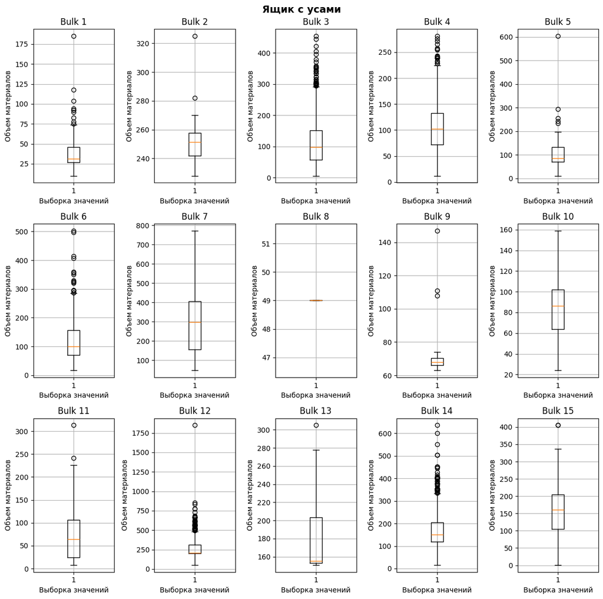

```python
fig, ax = plt.subplots(3, 5, figsize = (12, 12))
fig.suptitle('Ящик с усами', fontsize=14, fontweight='bold')
fig.subplots_adjust(top=0.9)

moustache = {}
param = {'Bulk 1':None, 'Bulk 2':None, 'Bulk 3':None, 'Bulk 4':None, 'Bulk 5':None,
         'Bulk 6':None, 'Bulk 7':None, 'Bulk 8':None, 'Bulk 9':None, 'Bulk 10':None,
         'Bulk 11':None, 'Bulk 12':None, 'Bulk 13':None, 'Bulk 14':None, 'Bulk 15':None}

x = 0
y = 0
for key, val in param.items():
    ax[x][y].boxplot(data_bulk_new[key].dropna())
    ax[x][y].grid()
    ax[x][y].set_title(key)
    ax[x][y].set_xlabel('Выборка значений')
    ax[x][y].set_ylabel('Объем материалов')
    y += 1
    if y == 5:
        y = 0
        if x < 3:
            x += 1

fig.tight_layout();
```

**Вывод**  
*Значения были получены в результате удаления пропусков, параметров представлено мало, поэтому, делать предположения о выбросах не приходится, предположительно, некторые значения могут выбиваться из общей массы специально.*

#### Распределение значений

Изучим распределение значений, вероятно, есть какие-то общие тенденции.

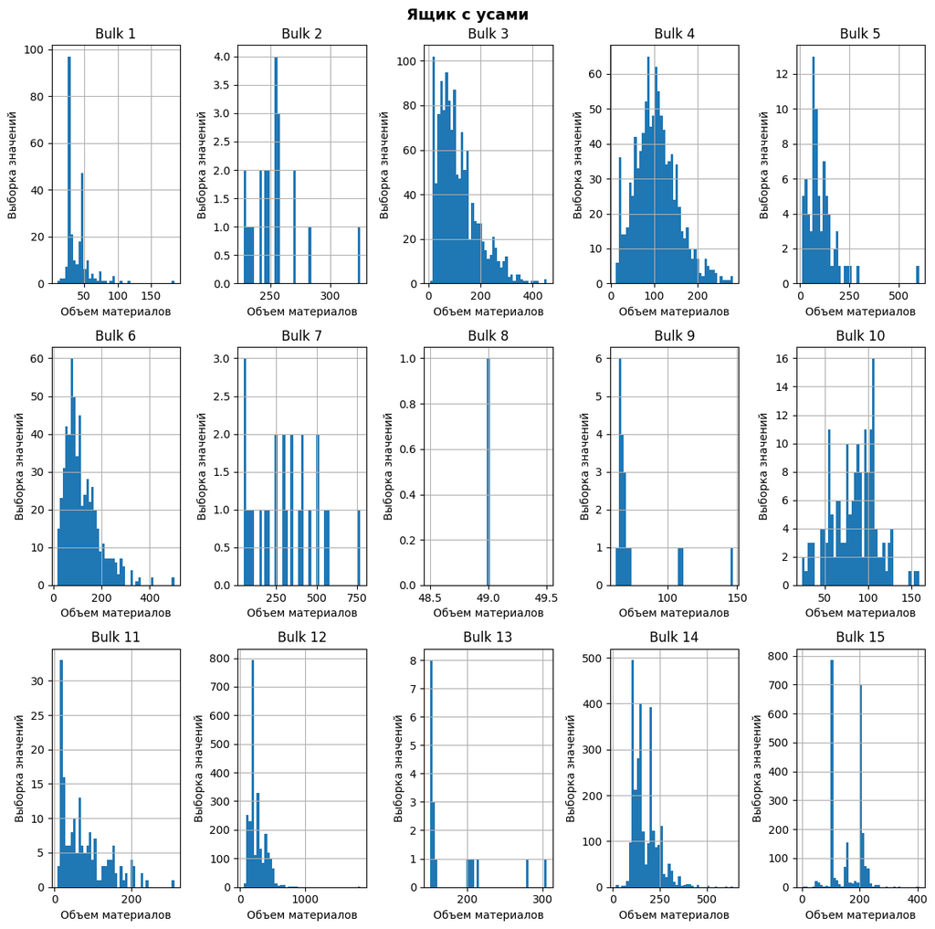

```python
fig, ax = plt.subplots(3, 5, figsize = (12, 12))
fig.suptitle('Ящик с усами', fontsize=14, fontweight='bold')
fig.subplots_adjust(top=0.9)

moustache = {}
param = {'Bulk 1':None, 'Bulk 2':None, 'Bulk 3':None, 'Bulk 4':None, 'Bulk 5':None,
         'Bulk 6':None, 'Bulk 7':None, 'Bulk 8':None, 'Bulk 9':None, 'Bulk 10':None,
         'Bulk 11':None, 'Bulk 12':None, 'Bulk 13':None, 'Bulk 14':None, 'Bulk 15':None}

x = 0
y = 0
for key, val in param.items():
    ax[x][y].hist(data_bulk_new[key].dropna(), bins=45)
    ax[x][y].grid()
    ax[x][y].set_title(key)
    ax[x][y].set_xlabel('Объем материалов')
    ax[x][y].set_ylabel('Выборка значений')
    y += 1
    if y == 5:
        y = 0
        if x < 3:
            x += 1

fig.tight_layout();
```

**Вывод**  
Значений мало, поэтому сложно говорить о нормальности распределения. Однако, можно наблюдать, что в ряде случаев некоторые объемы материала превалируют. В общем случае, значения больше 0, что исключает очевидные ошибки в переданных данных. Конкретно можно описать следующие столбцы для которых распределение:

- 'Bulk 3' скошено вправо;
- 'Bulk 4' можно предположить наличие симметрии(нормальное распределение);
- 'Bulk 6' скошено вправо;
- 'Bulk 10' скошено влево;
- 'Bulk 11' скошено вправо;
- 'Bulk 12' скошено вправо;
- 'Bulk 14' скошено вправо.

#### Корреляция значений

Значений мало, поэтому, чтобы не обманываться, возьмём столбцы, где значений, хотя бы 500

```python
list_corr_data = []
for el in data_bulk_new.columns:
    if (~data_bulk_new[el].isna()).sum() > 500:
        list_corr_data.append(el)

list_corr_data
```

```
['Bulk 3', 'Bulk 4', 'Bulk 6', 'Bulk 12', 'Bulk 14', 'Bulk 15']
```

```python
corr_data = data_bulk_new.corr()
corr_data.loc[list_corr_data, list_corr_data]
```

|  | Bulk 3 | Bulk 4 | Bulk 6 | Bulk 12 | Bulk 14 | Bulk 15 |
| --- | --- | --- | --- | --- | --- | --- |
| Bulk 3 | 1.000000 | -0.260918 | 0.253080 | 0.011648 | 0.026257 | -0.023689 |
| Bulk 4 | -0.260918 | 1.000000 | -0.333841 | 0.051112 | 0.022925 | 0.041190 |
| Bulk 6 | 0.253080 | -0.333841 | 1.000000 | -0.079822 | 0.154429 | -0.038363 |
| Bulk 12 | 0.011648 | 0.051112 | -0.079822 | 1.000000 | 0.427247 | 0.418691 |
| Bulk 14 | 0.026257 | 0.022925 | 0.154429 | 0.427247 | 1.000000 | 0.099170 |
| Bulk 15 | -0.023689 | 0.041190 | -0.038363 | 0.418691 | 0.099170 | 1.000000 |

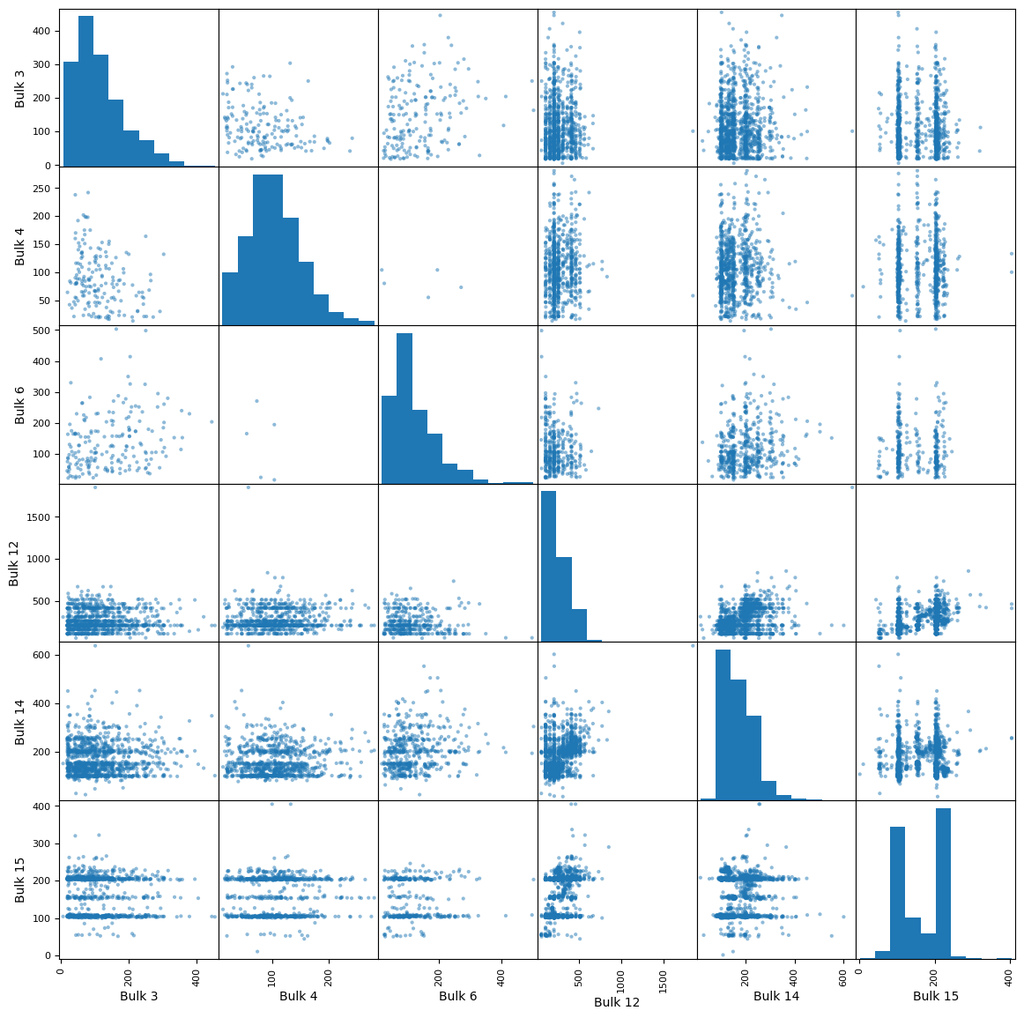

```python
pd.plotting.scatter_matrix(data_bulk_new.loc[:, list_corr_data], figsize=(14,14));
```

**Вывод**  
Сильных значений корреляции не наблюдается, макисимальное значение достигает 0.4.

#### Вывод

Результат изучения таблицы:

- обнаружено большое количество пропусков
- необходимо уточнить, по какому принципу вносились данные в столбцы, связана ли таблица с количеством итераций?
- нужно понять как работать с этой таблицей?
- столбцы нужно переименовать
- значения в таблице представлены в диапазоне от 1 до 3241, но всего 3129 вхождений. Нужно понять, почему включены не все партии(3241 значение)? Намеренно ли это сделано?
- вероятно, в таблице имеются выбросы, но самих значений достаточно мало, нужно понять, действительно ли это выбросы
- нужно уточнить у заказчика, какие параметры и таблицы могут повлиять на энергосбережение. Возможно эта таблица не пригодится.
- до уточнения данных у заказчика о корреляции и распределении можно не говорить, данных мало, предварительный анализ показал лишь 6 из 15 столбцов, доступных для обнаружения зависимостей. Корреляция наблюдается слабой, около 0.4 у некоторых столбцов.

### data_bulk_time_new

#### Первичный осмотр

```python
head_tail_info_desc(data_bulk_time_new);
```

```
.head()
```

| key | Bulk 1 | Bulk 2 | Bulk 3 | Bulk 4 | Bulk 5 | Bulk 6 | Bulk 7 | Bulk 8 | Bulk 9 | Bulk 10 | Bulk 11 | Bulk 12 | Bulk 13 | Bulk 14 | Bulk 15 |
| --- | --- | --- | --- | --- | --- | --- | --- | --- | --- | --- | --- | --- | --- | --- | --- |
| 1 | NaN | NaN | NaN | 2019-05-03 11:28:48 | NaN | NaN | NaN | NaN | NaN | NaN | NaN | 2019-05-03 11:24:31 | NaN | 2019-05-03 11:14:50 | 2019-05-03 11:10:43 |
| 2 | NaN | NaN | NaN | 2019-05-03 11:36:50 | NaN | NaN | NaN | NaN | NaN | NaN | NaN | 2019-05-03 11:53:30 | NaN | 2019-05-03 11:48:37 | 2019-05-03 11:44:39 |
| 3 | NaN | NaN | NaN | 2019-05-03 12:32:39 | NaN | NaN | NaN | NaN | NaN | NaN | NaN | 2019-05-03 12:27:13 | NaN | 2019-05-03 12:21:01 | 2019-05-03 12:16:16 |
| 4 | NaN | NaN | NaN | 2019-05-03 12:43:22 | NaN | NaN | NaN | NaN | NaN | NaN | NaN | 2019-05-03 12:58:00 | NaN | 2019-05-03 12:51:11 | 2019-05-03 12:46:36 |
| 5 | NaN | NaN | NaN | 2019-05-03 13:30:47 | NaN | NaN | NaN | NaN | NaN | NaN | NaN | 2019-05-03 13:30:47 | NaN | 2019-05-03 13:34:12 | 2019-05-03 13:30:47 |

```
.tail()
```

| key | Bulk 1 | Bulk 2 | Bulk 3 | Bulk 4 | Bulk 5 | Bulk 6 | Bulk 7 | Bulk 8 | Bulk 9 | Bulk 10 | Bulk 11 | Bulk 12 | Bulk 13 | Bulk 14 | Bulk 15 |
| --- | --- | --- | --- | --- | --- | --- | --- | --- | --- | --- | --- | --- | --- | --- | --- |
| 3237 | NaN | NaN | 2019-09-06 11:54:15 | NaN | NaN | NaN | NaN | NaN | NaN | NaN | NaN | 2019-09-06 11:49:45 | NaN | 2019-09-06 11:45:22 | 2019-09-06 11:40:06 |
| 3238 | NaN | NaN | 2019-09-06 12:26:52 | NaN | NaN | NaN | NaN | NaN | NaN | NaN | NaN | 2019-09-06 12:18:35 | NaN | 2019-09-06 12:31:49 | 2019-09-06 12:26:52 |
| 3239 | NaN | NaN | NaN | NaN | NaN | 2019-09-06 15:06:00 | NaN | NaN | NaN | NaN | NaN | 2019-09-06 15:01:44 | NaN | 2019-09-06 14:58:15 | 2019-09-06 14:48:06 |
| 3240 | NaN | NaN | NaN | NaN | NaN | 2019-09-06 16:24:28 | NaN | NaN | NaN | NaN | NaN | NaN | NaN | 2019-09-06 16:07:29 | 2019-09-06 16:01:34 |
| 3241 | NaN | NaN | NaN | NaN | NaN | NaN | NaN | NaN | NaN | NaN | NaN | NaN | NaN | 2019-09-06 17:26:33 | 2019-09-06 17:23:15 |

```
.info()
<class 'pandas.core.frame.DataFrame'>
Index: 3129 entries, 1 to 3241
Data columns (total 15 columns):
 #   Column   Non-Null Count  Dtype
---  ------   --------------  -----
 0   Bulk 1   252 non-null    object
 1   Bulk 2   22 non-null     object
 2   Bulk 3   1298 non-null   object
 3   Bulk 4   1014 non-null   object
 4   Bulk 5   77 non-null     object
 5   Bulk 6   576 non-null    object
 6   Bulk 7   25 non-null     object
 7   Bulk 8   1 non-null      object
 8   Bulk 9   19 non-null     object
 9   Bulk 10  176 non-null    object
 10  Bulk 11  177 non-null    object
 11  Bulk 12  2450 non-null   object
 12  Bulk 13  18 non-null     object
 13  Bulk 14  2806 non-null   object
 14  Bulk 15  2248 non-null   object
dtypes: object(15)
memory usage: 391.1+ KB
```

```
None
```

```
.describe()
```

|  | Bulk 1 | Bulk 2 | Bulk 3 | Bulk 4 | Bulk 5 | Bulk 6 | Bulk 7 | Bulk 8 | Bulk 9 | Bulk 10 | Bulk 11 | Bulk 12 | Bulk 13 | Bulk 14 | Bulk 15 |
| --- | --- | --- | --- | --- | --- | --- | --- | --- | --- | --- | --- | --- | --- | --- | --- |
| count | 252 | 22 | 1298 | 1014 | 77 | 576 | 25 | 1 | 19 | 176 | 177 | 2450 | 18 | 2806 | 2248 |
| unique | 252 | 22 | 1298 | 1014 | 77 | 576 | 25 | 1 | 19 | 176 | 177 | 2450 | 18 | 2806 | 2248 |
| top | 2019-05-03 17:42:46 | 2019-05-07 15:39:35 | 2019-05-03 20:40:25 | 2019-05-03 11:28:48 | 2019-05-07 15:19:17 | 2019-05-03 19:09:15 | 2019-05-07 18:11:01 | 2019-07-08 17:14:53 | 2019-05-14 11:57:58 | 2019-05-06 07:54:02 | 2019-05-05 23:43:24 | 2019-05-03 11:24:31 | 2019-05-05 02:10:21 | 2019-05-03 11:14:50 | 2019-05-03 11:10:43 |
| freq | 1 | 1 | 1 | 1 | 1 | 1 | 1 | 1 | 1 | 1 | 1 | 1 | 1 | 1 | 1 |

#### Вывод

Предварительный осмотр заставляет усомниться в корректности данных. Время в столбцах не соответствует порядковым номерам, т.е. не заметна временная последовательность от столбца к столбцу. Таблица сообщает о времени проведения операций в таблице data_bulk_new.

### data_gas_new

#### Первичный осмотр

```python
head_tail_info_desc(data_gas_new);
```

```
.head()
```

| key | Газ 1 |
| --- | --- |
| 1 | 29.749986 |
| 2 | 12.555561 |
| 3 | 28.554793 |
| 4 | 18.841219 |
| 5 | 5.413692 |

```
.tail()
```

| key | Газ 1 |
| --- | --- |
| 3237 | 5.543905 |
| 3238 | 6.745669 |
| 3239 | 16.023518 |
| 3240 | 11.863103 |
| 3241 | 12.680959 |

```
.info()
<class 'pandas.core.frame.DataFrame'>
Index: 3239 entries, 1 to 3241
Data columns (total 1 columns):
 #   Column  Non-Null Count  Dtype
---  ------  --------------  -----
 0   Газ 1   3239 non-null   float64
dtypes: float64(1)
memory usage: 50.6 KB
```

```
None
```

```
.describe()
```

|  | Газ 1 |
| --- | --- |
| count | 3239.000000 |
| mean | 11.002062 |
| std | 6.220327 |
| min | 0.008399 |
| 25% | 7.043089 |
| 50% | 9.836267 |
| 75% | 13.769915 |
| max | 77.995040 |

**Вывод:**

- представлен единственный столбец с наименованием 'Газ 1', вероятно есть еще данные, стоит уточнить;
- значение газа представлено в целом по партиям, либо взято среднее, либо продувка была один раз;
- 3239 вхождения найдено, с интервалом от 1 до 3241, значит, где-то есть пропуск;
- `describe` сообщает о возможных выбросах.

Получим имена партий не вошедших в таблицу

```python
mis_val = []
for i in range(data_gas_new.index.values.max()):
    if i+1 not in data_gas_new.index.values:
        mis_val.append(i+1)

print(mis_val)
```

```
[193, 259]
```

#### Выбросы

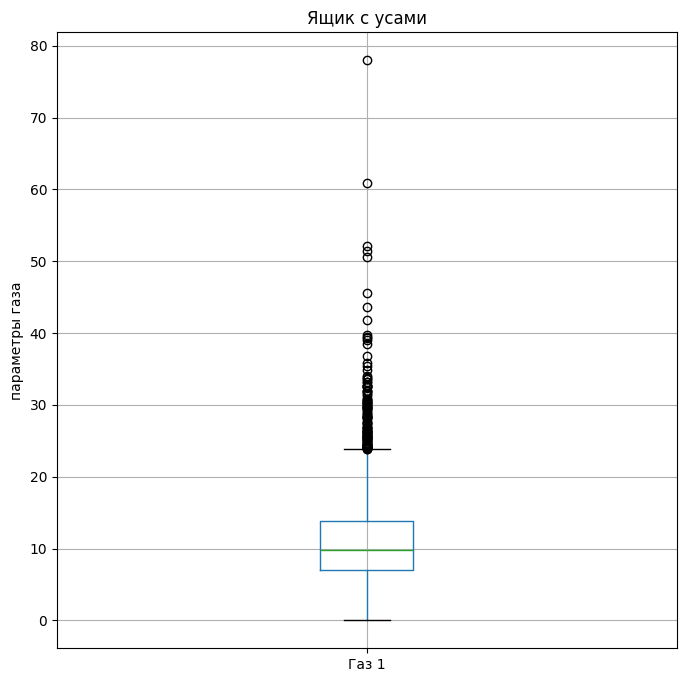

```python
b = data_gas_new.boxplot(figsize=(8,8), return_type='dict')
plt.ylabel('параметры газа')
plt.title('Ящик с усами');

moustache_dgn = {}
moustache_dgn['газ'] = [item.get_ydata()[1] for item in b['whiskers']]
```

**Вывод**  
Похожие выбросы наблюдаются и в таюлице data_arc_new, возможно это часть производственного процесса. Вопрос об удалении лучше поставить перед заказчиком.

#### Распределение значений

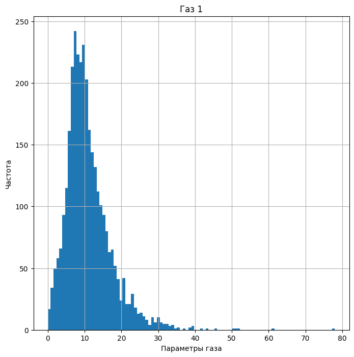

```python
data_gas_new.hist(bins=100, figsize=(8,8))
plt.ylabel('Частота')
plt.xlabel('Параметры газа');
```

**Вывод**  
Распределение не значительно скошено вправо.

#### Вывод

- представлен единственный столбец с наименованием 'Газ 1', вероятно есть еще данные, стоит уточнить;
- значение газа представлено в целом по партиям, либо взято среднее, либо продувка была один раз;
- 3239 вхождения найдено, с интервалом от 1 до 3241, найдены пропущенные партии;
- имеются выбросы, стоит уточнить на сколько они важны для производственного процесса;
- распределение значений практически нормальное, есть небольшое скос вправо.

### data_temp_new

#### Первичный осмотр

```python
head_tail_info_desc(data_temp_new);
```

```
.head()
```

| key | Время замера | Температура |
| --- | --- | --- |
| 1 | 2019-05-03 11:02:04 | 1571.0 |
| 1 | 2019-05-03 11:07:18 | 1604.0 |
| 1 | 2019-05-03 11:11:34 | 1618.0 |
| 1 | 2019-05-03 11:18:04 | 1601.0 |
| 1 | 2019-05-03 11:25:59 | 1606.0 |

```
.tail()
```

| key | Время замера | Температура |
| --- | --- | --- |
| 3241 | 2019-09-06 16:55:01 | NaN |
| 3241 | 2019-09-06 17:06:38 | NaN |
| 3241 | 2019-09-06 17:21:48 | NaN |
| 3241 | 2019-09-06 17:24:44 | NaN |
| 3241 | 2019-09-06 17:30:05 | NaN |

```
.info()
<class 'pandas.core.frame.DataFrame'>
Index: 18092 entries, 1 to 3241
Data columns (total 2 columns):
 #   Column        Non-Null Count  Dtype
---  ------        --------------  -----
 0   Время замера  18092 non-null  object
 1   Температура   14665 non-null  float64
dtypes: float64(1), object(1)
memory usage: 424.0+ KB
```

```
None
```

```
.describe()
```

|  | Температура |
| --- | --- |
| count | 14665.000000 |
| mean | 1590.722741 |
| std | 20.394381 |
| min | 1191.000000 |
| 25% | 1580.000000 |
| 50% | 1590.000000 |
| 75% | 1599.000000 |
| max | 1705.000000 |

Изучение количества вхождений

```python
data_temp_new.shape[0]- data_arc_new.shape[0]
```

```
3216
```

Изучение количества пропусков

```python
for el in data_temp_new.columns:
    ans = len(data_temp_new[data_temp_new[el].isna()])
    print(f'{el} {ans} ({ans/data_temp_new.shape[0] :.2}%)')
```

```
Время замера 0 (0.0%)
Температура 3427 (0.19%)
```

**Вывод**

- замеры температуры взяты между началом и концом нагрева дугой, т.е. данных должно быть больше, что и подтверждается в info. Значений на 3216 вхождений больше;
- предположительно данные представлены для каждой итерации;
- не все значения присутствуют, имеются пропуски;
- по полученным данным методом `describe` можно судить о более стабильных значениях, относительно других таблиц. Необходимо удостовериться, изучив выбросы и распределение значений;
- нужно уточнить у заказчика результаты измерения температуры чего конкретно представлены в наборе данных;
- можно предположить, что идеальная температура находится в районе 1590 градусов.

Изучим пропущенные партии

```python
mis_val = []
for i in range(data_temp_new.index.values.max()):
    if i+1 not in data_temp_new.index.values:
        mis_val.append(i+1)

print(mis_val)
```

```
[41, 42, 355, 382, 506, 529, 540, 607, 683, 710, 766, 1133, 1300, 1437, 2031, 2103, 2278, 2356, 2373, 2446, 2469, 2491, 2683, 3200, 3207]
```

#### Выбросы

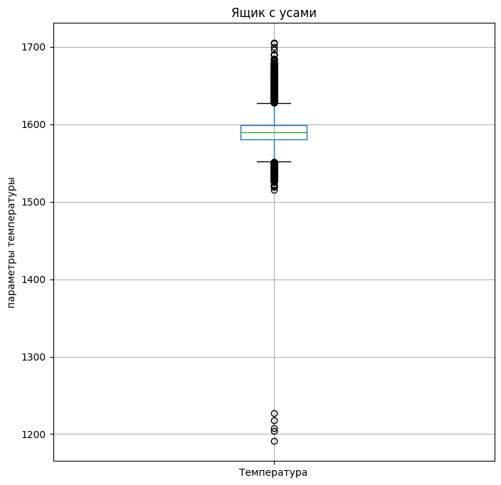

```python
b = data_temp_new.boxplot(figsize=(8,8), return_type='dict')
plt.ylabel('параметры температуры')
plt.title('Ящик с усами');

moustache_dtn = {}
moustache_dtn['температура'] = [item.get_ydata()[1] for item in b['whiskers']]
```

```python
print(moustache_dtn)
```

```
{'температура': [1552.0, 1627.0]}
```

**Вывод**

- температура плавления стали 1370-1530 градусов Цельсия. Чем обусловленны столь высокие и низкие значения не понятно. Надо уточнить температуру чего измеряют и на основе полученной информации принимать решение о сокращении значений.

#### Распределение значений

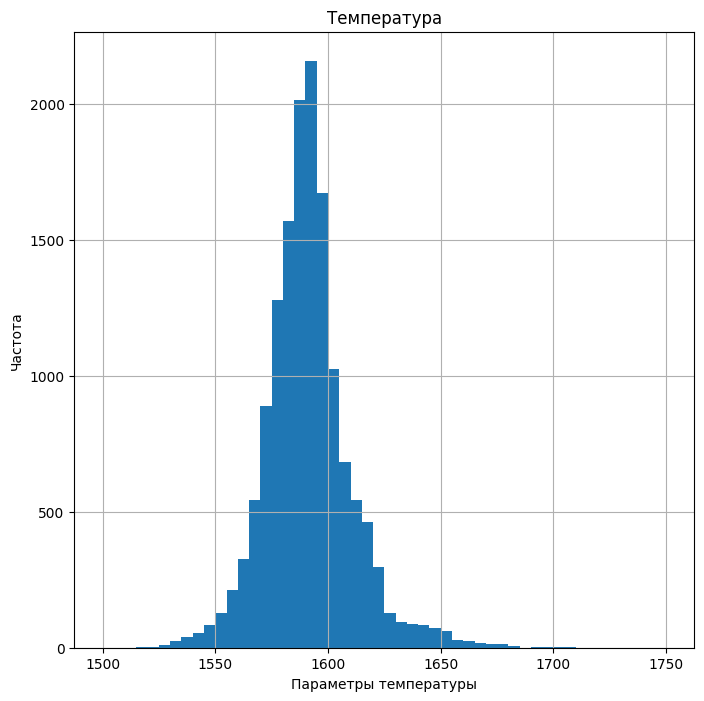

```python
data_temp_new.hist(bins=50, figsize=(8,8), range = (1500, 1750))
plt.ylabel('Частота')
plt.xlabel('Параметры температуры');
```

**Вывод**  
Представлено нормальное распределение значений

#### Вывод

- замеры температуры взяты между началом и концом нагрева дугой, т.е. данных больше, значений на 3216 вхождений больше;
- данные представлены почти для каждой итерации;
- не все значения присутствуют, имеются пропуски, около 19%;
- нужно уточнить у заказчика результаты измерения температуры чего конкретно представлены в наборе данных;
- имеются выбросы, необходимо утонить их природу и ценность, после можно приступать к обработке значений;
- данные распределены нормально.

### data_wire_new

#### Первичный осмотр

```python
head_tail_info_desc(data_wire_new);
```

```
.head()
```

| key | Wire 1 | Wire 2 | Wire 3 | Wire 4 | Wire 5 | Wire 6 | Wire 7 | Wire 8 | Wire 9 |
| --- | --- | --- | --- | --- | --- | --- | --- | --- | --- |
| 1 | 60.059998 | NaN | NaN | NaN | NaN | NaN | NaN | NaN | NaN |
| 2 | 96.052315 | NaN | NaN | NaN | NaN | NaN | NaN | NaN | NaN |
| 3 | 91.160157 | NaN | NaN | NaN | NaN | NaN | NaN | NaN | NaN |
| 4 | 89.063515 | NaN | NaN | NaN | NaN | NaN | NaN | NaN | NaN |
| 5 | 89.238236 | 9.11456 | NaN | NaN | NaN | NaN | NaN | NaN | NaN |

```
.tail()
```

| key | Wire 1 | Wire 2 | Wire 3 | Wire 4 | Wire 5 | Wire 6 | Wire 7 | Wire 8 | Wire 9 |
| --- | --- | --- | --- | --- | --- | --- | --- | --- | --- |
| 3237 | 38.088959 | NaN | NaN | NaN | NaN | NaN | NaN | NaN | NaN |
| 3238 | 56.128799 | NaN | NaN | NaN | NaN | NaN | NaN | NaN | NaN |
| 3239 | 143.357761 | NaN | NaN | NaN | NaN | NaN | NaN | NaN | NaN |
| 3240 | 34.070400 | NaN | NaN | NaN | NaN | NaN | NaN | NaN | NaN |
| 3241 | 63.117595 | NaN | NaN | NaN | NaN | NaN | NaN | NaN | NaN |

```
.info()
<class 'pandas.core.frame.DataFrame'>
Index: 3081 entries, 1 to 3241
Data columns (total 9 columns):
 #   Column  Non-Null Count  Dtype
---  ------  --------------  -----
 0   Wire 1  3055 non-null   float64
 1   Wire 2  1079 non-null   float64
 2   Wire 3  63 non-null     float64
 3   Wire 4  14 non-null     float64
 4   Wire 5  1 non-null      float64
 5   Wire 6  73 non-null     float64
 6   Wire 7  11 non-null     float64
 7   Wire 8  19 non-null     float64
 8   Wire 9  29 non-null     float64
dtypes: float64(9)
memory usage: 240.7 KB
```

```
None
```

```
.describe()
```

|  | Wire 1 | Wire 2 | Wire 3 | Wire 4 | Wire 5 | Wire 6 | Wire 7 | Wire 8 | Wire 9 |
| --- | --- | --- | --- | --- | --- | --- | --- | --- | --- |
| count | 3055.000000 | 1079.000000 | 63.000000 | 14.000000 | 1.000 | 73.000000 | 11.000000 | 19.000000 | 29.000000 |
| mean | 100.895853 | 50.577323 | 189.482681 | 57.442841 | 15.132 | 48.016974 | 10.039007 | 53.625193 | 34.155752 |
| std | 42.012518 | 39.320216 | 99.513444 | 28.824667 | NaN | 33.919845 | 8.610584 | 16.881728 | 19.931616 |
| min | 1.918800 | 0.030160 | 0.144144 | 24.148801 | 15.132 | 0.034320 | 0.234208 | 45.076721 | 4.622800 |
| 25% | 72.115684 | 20.193680 | 95.135044 | 40.807002 | 15.132 | 25.053600 | 6.762756 | 46.094879 | 22.058401 |
| 50% | 100.158234 | 40.142956 | 235.194977 | 45.234282 | 15.132 | 42.076324 | 9.017009 | 46.279999 | 30.066399 |
| 75% | 126.060483 | 70.227558 | 276.252014 | 76.124619 | 15.132 | 64.212723 | 11.886057 | 48.089603 | 43.862003 |
| max | 330.314424 | 282.780152 | 385.008668 | 113.231044 | 15.132 | 180.454575 | 32.847674 | 102.762401 | 90.053604 |

**Вывод:**

- имена столбцов нужно переименовать;
- очень много пропущенных значений, вероятно проволочые материалы добавлялись не всегда;
- представлено обобщенное значение по партиям, что подразумевает нумерация в столбцах не понятно;
- часть партий пропущена;
- о нормальности распределения и выбросах можно судить только по первым двум столбцам;

Изучим пропущенные партии

```python
mis_val = []
for i in range(data_wire_new.index.values.max()):
    if i+1 not in data_wire_new.index.values:
        mis_val.append(i+1)

print(mis_val)
```

```
[41, 42, 51, 52, 53, 54, 55, 56, 81, 82, 83, 84, 85, 88, 109, 195, 197, 209, 210, 211, 212, 269, 330, 331, 332, 355, 375, 376, 377, 378, 382, 506, 529, 540, 607, 683, 710, 711, 712, 713, 714, 715, 744, 748, 754, 755, 766, 796, 797, 798, 799, 800, 841, 929, 930, 931, 932, 933, 934, 1102, 1103, 1104, …
```

#### Выбросы

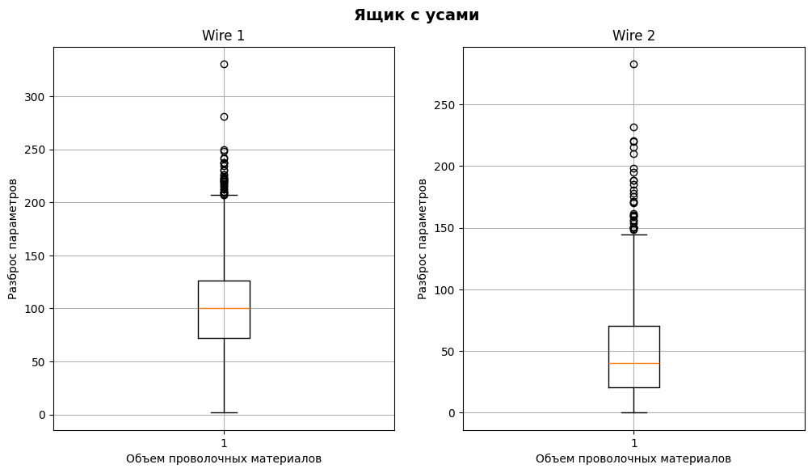

```python
fig, ax = plt.subplots(1, 2, figsize = (12, 6))
fig.suptitle('Ящик с усами', fontsize=14, fontweight='bold')
fig.subplots_adjust(top=0.9)

moustache_dwn = {}
param = {'Wire 1':None, 'Wire 2':None}
count = 0
for key, val in param.items():
    b = ax[count].boxplot(data_wire_new[key].dropna())
    #Выделение крайних усов боксплота
    moustache_dwn[key] = [item.get_ydata()[1] for item in b['whiskers']]
    ax[count].grid()
    ax[count].set_title(key)
    ax[count].set_xlabel('Объем проволочных материалов')
    ax[count].set_ylabel('Разброс параметров')
    count += 1
```

```python
print(moustache_dwn)
```

```
{'Wire 1': [1.9188, 206.668792], 'Wire 2': [0.03016, 144.289596]}
```

**Вывод**

- вероятно, что центральные значения соответствуют наиболее оптимальному решению в подготовке стали;
- стоит уточнить, почему столбцов 9, что за этим стоит;
- после уточнения, можно приступать к корректировке значений.

#### Распределение значений

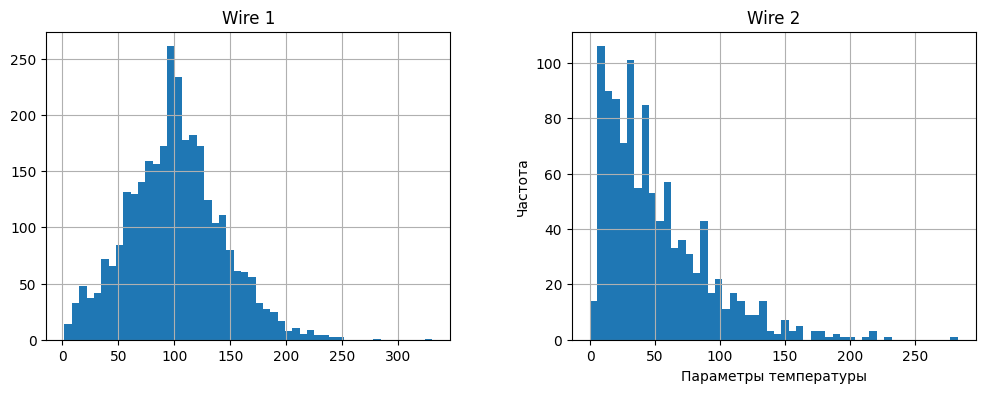

```python
data_wire_new.hist(column = ['Wire 1', 'Wire 2'], bins=50, figsize=(12,4))
plt.ylabel('Частота')
plt.xlabel('Параметры температуры');
```

**Вывод**

- 'Wire 1' распределение нормальное;
- 'Wire 2' распределение смещено вправо;
- возможно, стоит использовать только значимые параметры для решения задачи, параметры с малым количеством значений, можно не учитывать. Тем не менее лучше уточнить у заказчика.

#### Вывод

- имена столбцов нужно переименовать;
- очень много пропущенных значений, вероятно проволочые материалы добавлялись не всегда;
- представлено обобщенное значение по партиям, что подразумевает нумерация в столбцах не понятно;
- часть партий пропущена;
- о нормальности распределения и выбросах можно судить только по первым двум столбцам;
- вероятно, что центральные значения соответствуют наиболее оптимальному решению в подготовке стали;
- стоит уточнить, почему столбцов 9, что за этим стоит;
- после уточнения, можно приступать к корректировке значений;
- Столбцы:
  - 'Wire 1' распределение нормальное;
  - 'Wire 2' распределение смещено вправо;
- возможно, стоит использовать только значимые параметры для решения задачи, параметры с малым количеством значений, можно не учитывать. Тем не менее лучше уточнить у заказчика.

### data_wire_time_new

```python
head_tail_info_desc(data_wire_time_new);
```

```
.head()
```

| key | Wire 1 | Wire 2 | Wire 3 | Wire 4 | Wire 5 | Wire 6 | Wire 7 | Wire 8 | Wire 9 |
| --- | --- | --- | --- | --- | --- | --- | --- | --- | --- |
| 1 | 2019-05-03 11:06:19 | NaN | NaN | NaN | NaN | NaN | NaN | NaN | NaN |
| 2 | 2019-05-03 11:36:50 | NaN | NaN | NaN | NaN | NaN | NaN | NaN | NaN |
| 3 | 2019-05-03 12:11:46 | NaN | NaN | NaN | NaN | NaN | NaN | NaN | NaN |
| 4 | 2019-05-03 12:43:22 | NaN | NaN | NaN | NaN | NaN | NaN | NaN | NaN |
| 5 | 2019-05-03 13:20:44 | 2019-05-03 13:15:34 | NaN | NaN | NaN | NaN | NaN | NaN | NaN |

```
.tail()
```

| key | Wire 1 | Wire 2 | Wire 3 | Wire 4 | Wire 5 | Wire 6 | Wire 7 | Wire 8 | Wire 9 |
| --- | --- | --- | --- | --- | --- | --- | --- | --- | --- |
| 3237 | 2019-09-06 11:33:38 | NaN | NaN | NaN | NaN | NaN | NaN | NaN | NaN |
| 3238 | 2019-09-06 12:18:35 | NaN | NaN | NaN | NaN | NaN | NaN | NaN | NaN |
| 3239 | 2019-09-06 14:36:11 | NaN | NaN | NaN | NaN | NaN | NaN | NaN | NaN |
| 3240 | 2019-09-06 15:33:55 | NaN | NaN | NaN | NaN | NaN | NaN | NaN | NaN |
| 3241 | 2019-09-06 17:10:06 | NaN | NaN | NaN | NaN | NaN | NaN | NaN | NaN |

```
.info()
<class 'pandas.core.frame.DataFrame'>
Index: 3081 entries, 1 to 3241
Data columns (total 9 columns):
 #   Column  Non-Null Count  Dtype
---  ------  --------------  -----
 0   Wire 1  3055 non-null   object
 1   Wire 2  1079 non-null   object
 2   Wire 3  63 non-null     object
 3   Wire 4  14 non-null     object
 4   Wire 5  1 non-null      object
 5   Wire 6  73 non-null     object
 6   Wire 7  11 non-null     object
 7   Wire 8  19 non-null     object
 8   Wire 9  29 non-null     object
dtypes: object(9)
memory usage: 240.7+ KB
```

```
None
```

```
.describe()
```

|  | Wire 1 | Wire 2 | Wire 3 | Wire 4 | Wire 5 | Wire 6 | Wire 7 | Wire 8 | Wire 9 |
| --- | --- | --- | --- | --- | --- | --- | --- | --- | --- |
| count | 3055 | 1079 | 63 | 14 | 1 | 73 | 11 | 19 | 29 |
| unique | 3055 | 1079 | 63 | 14 | 1 | 73 | 11 | 19 | 29 |
| top | 2019-05-03 11:06:19 | 2019-05-03 13:15:34 | 2019-05-04 04:34:27 | 2019-05-07 15:19:17 | 2019-08-13 06:14:30 | 2019-05-07 14:46:05 | 2019-07-27 05:49:05 | 2019-05-14 11:29:24 | 2019-05-04 17:21:27 |
| freq | 1 | 1 | 1 | 1 | 1 | 1 | 1 | 1 | 1 |

#### Вывод

- имена столбцов нужно переименовать;
- заметно большое количество пропусков, в целом, количество вхождений в data_wire_new и этом столбце совпадают;
- есть необходимость в изменении типов данных;

### Сравнение временных интервалов

Изучим порядок проведения операций

```python
def time_info():
    def make_df(col_name):
        dict_wire = {'Bulk 1': 'Гранулы 1', 'Bulk 4': 'Гранулы 4',
                     'Bulk 12': 'Гранулы 12', 'Bulk 14': 'Гранулы 14', 'Bulk 15': 'Гранулы 15'}
        dbtn4 = pd.DataFrame(dbtn[col_name].values, index=[dict_wire[col_name]], columns=['Начало нагрева дугой'])
        return dbtn4
    # data_arc_new
    dan = data_arc_new.loc[1].copy()
    dan.loc[1, ['Начало нагрева дугой']] = data_arc_new.loc[1, ['Начало нагрева дугой']]['Начало нагрева дугой'].dt.time
    dan.loc[1, ['Конец нагрева дугой']] = data_arc_new.loc[1, ['Конец нагрева дугой']]['Конец нагрева дугой'].dt.time
    dan.index = ['Нагрев дугой' for i in range(dan.shape[0])]
    # data_bulk_time_new
    dbtn = data_bulk_time_new.loc[:1, :].copy()
    dbtn['Bulk 4'] = pd.to_datetime(dbtn['Bulk 4'], format='%Y-%m-%d %H:%M:%S').dt.time
    dbtn['Bulk 12'] = pd.to_datetime(dbtn['Bulk 12'], format='%Y-%m-%d %H:%M:%S').dt.time
    dbtn['Bulk 14'] = pd.to_datetime(dbtn['Bulk 14'], format='%Y-%m-%d %H:%M:%S').dt.time
    dbtn['Bulk 15'] = pd.to_datetime(dbtn['Bulk 15'], format='%Y-%m-%d %H:%M:%S').dt.time
    dbtn = dbtn.loc[1:, ['Bulk 4', 'Bulk 12', 'Bulk 14', 'Bulk 15']]
    dbtn4 = make_df('Bulk 4')
    dbtn12 = make_df('Bulk 12')
    dbtn14 = make_df('Bulk 14')
    dbtn15 = make_df('Bulk 15')
    # data_temp_new
    dtn = data_temp_new.loc[:1, :].copy()
    dtn['Время замера'] = pd.to_datetime(dtn['Время замера'], format='%Y-%m-%d %H:%M:%S').dt.time
    dtn.index = ['Измерение температуры' for i in range(dtn.shape[0])]
    dtn.columns = ['Начало нагрева дугой', 'Температура']
    # data_wire_time_new
    dwtn = data_wire_time_new.loc[1, ['Wire 1']].copy()
    dwtn = pd.to_datetime(dwtn, format='%Y-%m-%d %H:%M:%S').dt.time
    dwtn = pd.DataFrame(dwtn.values, index=['проволочное_1'], columns=['Начало нагрева дугой'])

    dan = pd.concat([dan, dbtn4,  dbtn12, dbtn14,  dbtn15, dtn, dwtn])
    dan = dan.loc[:, ['Начало нагрева дугой', 'Конец нагрева дугой']]
    dan.columns = ['Время операции', 'Конец операции']

    return(dan.sort_values(by='Время операции'))

time_info()
```

|  | Время операции | Конец операции |
| --- | --- | --- |
| Измерение температуры | 11:02:04 | NaN |
| Нагрев дугой | 11:02:14 | 11:06:02 |
| проволочное_1 | 11:06:19 | NaN |
| Измерение температуры | 11:07:18 | NaN |
| Нагрев дугой | 11:07:28 | 11:10:33 |
| Гранулы 15 | 11:10:43 | NaN |
| Измерение температуры | 11:11:34 | NaN |
| Нагрев дугой | 11:11:44 | 11:14:36 |
| Гранулы 14 | 11:14:50 | NaN |
| Измерение температуры | 11:18:04 | NaN |
| Нагрев дугой | 11:18:14 | 11:24:19 |
| Гранулы 12 | 11:24:31 | NaN |
| Измерение температуры | 11:25:59 | NaN |
| Нагрев дугой | 11:26:09 | 11:28:37 |
| Гранулы 4 | 11:28:48 | NaN |
| Измерение температуры | 11:30:38 | NaN |

### Вывод

Вывод будет распределен по каждой таблице и отдельно для всех

1. data_arc_new(данные об электродах):
   - данные представлены за 2019 год, с 3 мая по 6 сентября;
   - имеется 3241 партия и 14876 значений, что означает примерно 4.59 итерации на сборку;
   - обнаружены выбросы в значениях активной и реактивнвой мощностей;
   - распределение данных в столбцах 'Реактивная мощность' и 'Активная мощность' смещено вправо;
   - наблюдается сильная корреляция, порядка 0.96.

     Вопросы к заказчику:
   - необходимы граничные значения активной и реактивной мощности
   - партии представлены с промежутками в данных. Так и должно быть?
2. data_bulk_new(данные о подаче сыпучих материалов (объём)):
   - обнаружено большое количество пропусков, вероятно из-за специфики производства;
   - столбцы нужно переименовать;
   - значения в таблице представлены в диапазоне от 1 до 3241, но всего 3129 вхождений;
   - имеются выбросы, но из-за малого количества значений точно понять нельзя.

     Вопросы к заказчику:
   - чем являются 'builk' — ёмкость? Почему столбцов 15?
   - почему включены не все партии(3241 значение)? Намеренно ли это сделано?
   - все ли данные предоставлены?
   - в таблице, значения сильно разняться, что позволяет сделать предположение о сильном отклонении от нормы значения(т.е. о выбросе). Какие параметры можно считать выбросами(например 1849 и 1)?
3. data_bulk_time_new(данные о подаче сыпучих материалов (время)):
   - между стобцами 'Builk 1' - 'Builk 15' можно наблюдать отсутствие в последовательности во времени;
   - столбцы стоит переименовать и привестви к другому типу данных;

     Вопросы к заказчику:
   - между стобцами 'Builk 1' - 'Builk 15' можно наблюдать отсутствие в последовательности во времени, так и должно быть?;
4. data_gas_new(данные о продувке сплава газом):
   - представлен единственный столбец с наименованием 'Газ 1';
   - значение газа представлено в целом по партиям, либо взято среднее, либо продувка была один раз;
   - 3239 вхождения найдено, с интервалом от 1 до 3241, найдены пропущенные партии;
   - имеются выбросы;
   - распределение значений практически нормальное, есть небольшое скос вправо.

     Вопросы к заказчику:
   - как осуществляется продувка газом, процесс одноразовый для всех итераций партии, либо взято среднее?;
   - в какой системе измерений представлены значения в таблице?;
   - есть ли рекомендованные граничные значенния у параметров газа?;
5. data_temp_new(результаты измерения температуры):
   - замеры температуры взяты между началом и концом нагрева дугой, т.е. данных больше, значений на 3216 вхождений больше;
   - данные представлены почти для каждой итерации;
   - не все значения присутствуют, имеются пропуски, около 19%;
   - данные распределены нормально;
   - В данных представлено минимальное значение в 1191 и 1705.

     Вопросы к заказчику:
   - параметры в таблице представляют температуру стали? Значения представлены в градусах Цельсия?;
   - почему имеется такой большое количество пропусков в значениях температуры, сталь достигла необходимых параметров?;
   - какие граничные значения температуры?
6. data_wire_new(данные о проволочных материалах (объём)):
   - имена столбцов нужно переименовать;
   - очень много пропущенных значений, вероятно проволочые материалы добавлялись не всегда;
   - представлено обобщенное значение по партиям, что подразумевает нумерация в столбцах не понятно;
   - часть партий пропущена;
   - о нормальности распределения и выбросах можно судить только по первым двум столбцам;
   - вероятно, что центральные значения соответствуют наиболее оптимальному решению в подготовке стали;
   - Столбцы:
     - 'Wire 1' распределение нормальное;
     - 'Wire 2' распределение смещено вправо;

     Вопросы к заказчику:
   - почему в таблице представлено 9 столбцов, что за этим стоит?;
   - почему часть партий может быть пропущена?;
   - есть ли граничные значения?;
   - почему столько пропусков?.
7. ata_wire_time_new(данные о проволочных материалах):
   - имена столбцов нужно переименовать;
   - аметно большое количество пропусков, в целом, количество вхождений в data_wire_new и этом столбце совпадают;
   - есть необходимость в изменении типов данных;

Общие вопросы:

1. как прогнозная модель по температуре поможет в энергосбережении;
2. предположительно, чем больше активная мощность и меньше реактивная, тем лучше, существует ли какая-то формула для получения коэффициента?
3. есть ли какие-то дополнительные данные, позволяющие определить достижение целевого химического состава и оптимальную температуры плавки?

**Предварительный план работы**

1. Подготовка и анализ;
2. Предобработка;
3. Подготовка признаков;
4. Обучение;
5. Выводы

## Предобработка

По итогам встречи с заказчиком были получены ответы на интересующие вопросы и намечен курс дальнейшей работы. Вначале будет проведена обработка данных в таблицах, следом, данные будут агрегированы и объеденены. Некоторые таблицы не будут включены в итоговую агрегирующую.

### data_arc_new

Добавим секунды как новый признак

```python
data_arc_new['seconds'] = (data_arc_new['Конец нагрева дугой'] - data_arc_new['Начало нагрева дугой']).dt.seconds
```

Проверим на пропуски

```python
data_arc_new['Активная мощность'].isna().sum()
```

```
0
```

Посчитаем итерации каждой партии. Сформирует стобец.

```python
iter_arc = data_arc_new.loc[:, ['Начало нагрева дугой']].copy()
iter_arc.columns = ['итер_дуг']
iter_arc = iter_arc.groupby('key').count()
```

#### Агрегирование

Агрегируем данные времени по партиям

```python
agg_dict = {'median':'дуга_сек(median)',
           'sum':'дуга_сек(sum)'}

agg_sec = data_arc_new['seconds'].groupby('key').agg(list(agg_dict.keys()))
agg_sec.columns = list(agg_dict.values())
```

```python
agg_sec.head()
```

| key | дуга_сек(median) | дуга_сек(sum) |
| --- | --- | --- |
| 1 | 185.0 | 1098 |
| 2 | 173.5 | 811 |
| 3 | 109.0 | 655 |
| 4 | 182.0 | 741 |
| 5 | 191.5 | 869 |

Агрегируем данные, используя, только один из факторов, между которыми корреляция почти 1, тот, который представляет большую ценность. Добавим несколько агрегаторов, ради эксперимента.

```python
funs_col = {'median':'акт_мощ(median)',
            'sum':'акт_мощ(sum)'}

agg_data_arc_new = (pd.pivot_table(data_arc_new.loc[:, ['Активная мощность']],
                                   index='key', aggfunc=list(funs_col.keys()))

                   )

agg_data_arc_new.columns = list(funs_col.values())
```

```python
list(funs_col.values())
```

```
['акт_мощ(median)', 'акт_мощ(sum)']
```

```python
agg_data_arc_new.head()
```

| key | акт_мощ(median) | акт_мощ(sum) |
| --- | --- | --- |
| 1 | 0.580313 | 3.036730 |
| 2 | 0.545710 | 2.139408 |
| 3 | 0.774632 | 4.063641 |
| 4 | 0.753970 | 2.706489 |
| 5 | 0.517715 | 2.252950 |

Сформируем таблицу признаков, используя `join`

```python
agg_data_arc_new = agg_data_arc_new.join(agg_sec, on='key', rsuffix='_sec')
```

```python
agg_data_arc_new.head()
```

| key | акт_мощ(median) | акт_мощ(sum) | дуга_сек(median) | дуга_сек(sum) |
| --- | --- | --- | --- | --- |
| 1 | 0.580313 | 3.036730 | 185.0 | 1098 |
| 2 | 0.545710 | 2.139408 | 173.5 | 811 |
| 3 | 0.774632 | 4.063641 | 109.0 | 655 |
| 4 | 0.753970 | 2.706489 | 182.0 | 741 |
| 5 | 0.517715 | 2.252950 | 191.5 | 869 |

*Вот и первая таблица готова!*

### data_bulk_new

```python
data_bulk_new.info();
```

```
<class 'pandas.core.frame.DataFrame'>
Index: 3129 entries, 1 to 3241
Data columns (total 15 columns):
 #   Column   Non-Null Count  Dtype
---  ------   --------------  -----
 0   Bulk 1   252 non-null    float64
 1   Bulk 2   22 non-null     float64
 2   Bulk 3   1298 non-null   float64
 3   Bulk 4   1014 non-null   float64
 4   Bulk 5   77 non-null     float64
 5   Bulk 6   576 non-null    float64
 6   Bulk 7   25 non-null     float64
 7   Bulk 8   1 non-null      float64
 8   Bulk 9   19 non-null     float64
 9   Bulk 10  176 non-null    float64
 10  Bulk 11  177 non-null    float64
 11  Bulk 12  2450 non-null   float64
 12  Bulk 13  18 non-null     float64
 13  Bulk 14  2806 non-null   float64
 14  Bulk 15  2248 non-null   float64
dtypes: float64(15)
memory usage: 391.1 KB
```

Избавимся от пропусков в таблице, заполним значения 0(допустимое значение по предобработке и смыслу).

```python
data_bulk_new = data_bulk_new.fillna(0)
```

Не все столбцы заполнены, предположительно присадок не было. Для анализа используем ниболее значимые признаки, остальные попробуем объединить в один столбец и посмотрим что получится(получено опытным путём).

Наиболее полные столбцы:

- 'Bulk 12'
- 'Bulk 14'
- 'Bulk 15'

Столбцы для объединения:

- 'Bulk 1'
- 'Bulk 2'
- 'Bulk 5'
- 'Bulk 6'
- 'Bulk 7'
- 'Bulk 8'
- 'Bulk 9'
- 'Bulk 10'
- 'Bulk 11'
- 'Bulk 13'
- 'Bulk 3'
- 'Bulk 4'

```python
agg_data_bulk_new = data_bulk_new.loc[:, ['Bulk 12', 'Bulk 14', 'Bulk 15']]
```

```python
agg_data_bulk_new['Bulk other'] = 0
list_sum = ['Bulk 1', 'Bulk 2', 'Bulk 5', 'Bulk 6', 'Bulk 7', 'Bulk 8', 'Bulk 9', 'Bulk 10',
            'Bulk 11', 'Bulk 13', 'Bulk 4', 'Bulk 3'
           ]

for el in list_sum:
    agg_data_bulk_new['Bulk other'] += data_bulk_new[el]
```

Изучим количество 0 значений в объединении

```python
agg_data_bulk_new.loc[agg_data_bulk_new['Bulk other'] != 0, ['Bulk other']].shape[0]
```

```
2673
```

Остаётся переименовать столбцы

```python
agg_data_bulk_new.columns = ['гранулы_12', 'гранулы_14', 'гранулы_15', 'другие_гранулы']
```

```python
agg_data_bulk_new.head()
```

| key | гранулы_12 | гранулы_14 | гранулы_15 | другие_гранулы |
| --- | --- | --- | --- | --- |
| 1 | 206.0 | 150.0 | 154.0 | 43.0 |
| 2 | 206.0 | 149.0 | 154.0 | 73.0 |
| 3 | 205.0 | 152.0 | 153.0 | 34.0 |
| 4 | 207.0 | 153.0 | 154.0 | 81.0 |
| 5 | 203.0 | 151.0 | 152.0 | 78.0 |

*Готова вторая таблица*

### data_gas_new

Столбец обладает единственным, уже агрегированным параметром, некоторые партии отсутствуют.

```python
data_gas_new.head()
```

| key | Газ 1 |
| --- | --- |
| 1 | 29.749986 |
| 2 | 12.555561 |
| 3 | 28.554793 |
| 4 | 18.841219 |
| 5 | 5.413692 |

```python
edit_data_gas_new = data_gas_new.copy()
edit_data_gas_new.columns = ['газ']
```

*Таблица готова*

### data_temp_new

Температура является ключевым признаком, соответственно, если есть пропуски, то необходимо удалять всю партию.

```python
data_temp_new.head()
```

| key | Время замера | Температура |
| --- | --- | --- |
| 1 | 2019-05-03 11:02:04 | 1571.0 |
| 1 | 2019-05-03 11:07:18 | 1604.0 |
| 1 | 2019-05-03 11:11:34 | 1618.0 |
| 1 | 2019-05-03 11:18:04 | 1601.0 |
| 1 | 2019-05-03 11:25:59 | 1606.0 |

Определим партии, где пропусков нет

```python
pass_index = set(data_temp_new.loc[data_temp_new['Температура'].isna(), ['Температура']].index)
edit_data_temp_new = data_temp_new.loc[~data_temp_new['Температура'].index.isin(pass_index),['Температура']]
edit_data_temp_new.columns = ['температура']
```

#### Оптимальная температура плавки

Из описания этапов обработки металла ясно, что наиболее важным этапом в цикле является последний, так как обладает необходимым химическим составом и температурой плавки. Стоит дополнительно исследовать последний замер температуры в цикле.

```python
edit_data_temp_new.groupby('key').last().describe()
```

|  | температура |
| --- | --- |
| count | 2477.000000 |
| mean | 1595.334275 |
| std | 16.019339 |
| min | 1541.000000 |
| 25% | 1587.000000 |
| 50% | 1593.000000 |
| 75% | 1599.000000 |
| max | 1700.000000 |

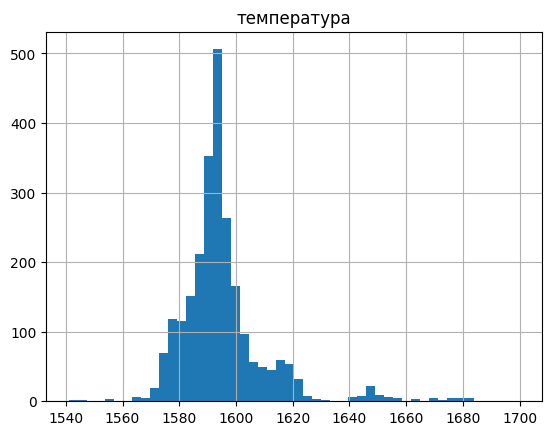

```python
edit_data_temp_new.groupby('key').last().hist(bins = 50);
```

*Распределение похоже на нормальное*

#### Агрегирование

```python
edit_data_temp_new = edit_data_temp_new.groupby('key').agg(['last', 'first'])
edit_data_temp_new.columns = ['температура', 'т_начальная']
edit_data_temp_new.head()
```

| key | температура | т_начальная |
| --- | --- | --- |
| 1 | 1613.0 | 1571.0 |
| 2 | 1602.0 | 1581.0 |
| 3 | 1599.0 | 1596.0 |
| 4 | 1625.0 | 1601.0 |
| 5 | 1602.0 | 1576.0 |

Получим информацию о количестве итераций

```python
iter_temp = data_temp_new.loc[:, ['Температура']].copy()
iter_temp.columns = ['итер_темп']
iter_temp = iter_temp.groupby('key').count()
```

```python
edit_data_temp_new.head()
```

| key | температура | т_начальная |
| --- | --- | --- |
| 1 | 1613.0 | 1571.0 |
| 2 | 1602.0 | 1581.0 |
| 3 | 1599.0 | 1596.0 |
| 4 | 1625.0 | 1601.0 |
| 5 | 1602.0 | 1576.0 |

### data_wire_new

Обработаем эту таблицу так же, как и data_bulk_new. Объединим часть столбцов.

```python
data_wire_new.info();
```

```
<class 'pandas.core.frame.DataFrame'>
Index: 3081 entries, 1 to 3241
Data columns (total 9 columns):
 #   Column  Non-Null Count  Dtype
---  ------  --------------  -----
 0   Wire 1  3055 non-null   float64
 1   Wire 2  1079 non-null   float64
 2   Wire 3  63 non-null     float64
 3   Wire 4  14 non-null     float64
 4   Wire 5  1 non-null      float64
 5   Wire 6  73 non-null     float64
 6   Wire 7  11 non-null     float64
 7   Wire 8  19 non-null     float64
 8   Wire 9  29 non-null     float64
dtypes: float64(9)
memory usage: 240.7 KB
```

```python
data_wire_new = data_wire_new.fillna(0)
```

```python
edit_data_wire_new = data_wire_new.loc[:, ['Wire 1']]
```

```python
edit_data_wire_new['wire_other'] = 0
add_list = ['Wire 2', 'Wire 3', 'Wire 4', 'Wire 5', 'Wire 6', 'Wire 7',  'Wire 8', 'Wire 9']

for el in add_list:
    edit_data_wire_new['wire_other'] += data_wire_new[el]
```

Оценим сколько значений будет в объединенном столбце

```python
edit_data_wire_new.loc[edit_data_wire_new['wire_other'] != 0, ['wire_other']].count()
```

```
wire_other    1164
dtype: int64
```

```python
edit_data_wire_new.columns = ['проволчное_1', 'проволочное_остальное']
edit_data_wire_new.head()
```

| key | проволчное_1 | проволочное_остальное |
| --- | --- | --- |
| 1 | 60.059998 | 0.00000 |
| 2 | 96.052315 | 0.00000 |
| 3 | 91.160157 | 0.00000 |
| 4 | 89.063515 | 0.00000 |
| 5 | 89.238236 | 9.11456 |

### Объединение

Главной таблицей к которой будем присоеденять станет та, где находится целевой признак. Объединим таблицы:

- edit_data_temp_new;
- agg_data_arc_new;
- agg_data_bulk_new;
- edit_data_gas_new;
- edit_data_wire_new;
- iter_arc;
- iter_temp.

```python
table_join = [agg_data_arc_new, agg_data_bulk_new, edit_data_gas_new, edit_data_wire_new, iter_arc, iter_temp]
data = edit_data_temp_new.join(table_join)
data.head()
```

| key | температура | т_начальная | акт_мощ(median) | акт_мощ(sum) | дуга_сек(median) | дуга_сек(sum) | гранулы_12 | гранулы_14 | гранулы_15 | другие_гранулы | газ | проволчное_1 | проволочное_остальное | итер_дуг | итер_темп |
| --- | --- | --- | --- | --- | --- | --- | --- | --- | --- | --- | --- | --- | --- | --- | --- |
| 1 | 1613.0 | 1571.0 | 0.580313 | 3.036730 | 185.0 | 1098.0 | 206.0 | 150.0 | 154.0 | 43.0 | 29.749986 | 60.059998 | 0.00000 | 5.0 | 6.0 |
| 2 | 1602.0 | 1581.0 | 0.545710 | 2.139408 | 173.5 | 811.0 | 206.0 | 149.0 | 154.0 | 73.0 | 12.555561 | 96.052315 | 0.00000 | 4.0 | 5.0 |
| 3 | 1599.0 | 1596.0 | 0.774632 | 4.063641 | 109.0 | 655.0 | 205.0 | 152.0 | 153.0 | 34.0 | 28.554793 | 91.160157 | 0.00000 | 5.0 | 6.0 |
| 4 | 1625.0 | 1601.0 | 0.753970 | 2.706489 | 182.0 | 741.0 | 207.0 | 153.0 | 154.0 | 81.0 | 18.841219 | 89.063515 | 0.00000 | 4.0 | 5.0 |
| 5 | 1602.0 | 1576.0 | 0.517715 | 2.252950 | 191.5 | 869.0 | 203.0 | 151.0 | 152.0 | 78.0 | 5.413692 | 89.238236 | 9.11456 | 4.0 | 5.0 |

```python
shape_info = data.shape[0]
shape_info
```

```
2477
```

Изучим пропуски в таблице

```python
pass_list = {}
for el in data.columns:
    pass_list[el] = data[el].isna().sum()
print(pass_list)
```

```
{'температура': 0, 'т_начальная': 0, 'акт_мощ(median)': 2, 'акт_мощ(sum)': 2, 'дуга_сек(median)': 2, 'дуга_сек(sum)': 2, 'гранулы_12': 69, 'гранулы_14': 69, 'гранулы_15': 69, 'другие_гранулы': 69, 'газ': 2, 'проволчное_1': 104, 'проволочное_остальное': 104, 'итер_дуг': 2, 'итер_темп': 0}
```

Очистим набор данных от пропусков

```python
data = data.dropna()
```

Изучим какой объем значений был отброшен

```python
print(f'Мы удалили {1 - (data.shape[0]/shape_info) :.2f}% данных')
```

```
Мы удалили 0.06% данных
```

```python
data.head()
```

| key | температура | т_начальная | акт_мощ(median) | акт_мощ(sum) | дуга_сек(median) | дуга_сек(sum) | гранулы_12 | гранулы_14 | гранулы_15 | другие_гранулы | газ | проволчное_1 | проволочное_остальное | итер_дуг | итер_темп |
| --- | --- | --- | --- | --- | --- | --- | --- | --- | --- | --- | --- | --- | --- | --- | --- |
| 1 | 1613.0 | 1571.0 | 0.580313 | 3.036730 | 185.0 | 1098.0 | 206.0 | 150.0 | 154.0 | 43.0 | 29.749986 | 60.059998 | 0.00000 | 5.0 | 6.0 |
| 2 | 1602.0 | 1581.0 | 0.545710 | 2.139408 | 173.5 | 811.0 | 206.0 | 149.0 | 154.0 | 73.0 | 12.555561 | 96.052315 | 0.00000 | 4.0 | 5.0 |
| 3 | 1599.0 | 1596.0 | 0.774632 | 4.063641 | 109.0 | 655.0 | 205.0 | 152.0 | 153.0 | 34.0 | 28.554793 | 91.160157 | 0.00000 | 5.0 | 6.0 |
| 4 | 1625.0 | 1601.0 | 0.753970 | 2.706489 | 182.0 | 741.0 | 207.0 | 153.0 | 154.0 | 81.0 | 18.841219 | 89.063515 | 0.00000 | 4.0 | 5.0 |
| 5 | 1602.0 | 1576.0 | 0.517715 | 2.252950 | 191.5 | 869.0 | 203.0 | 151.0 | 152.0 | 78.0 | 5.413692 | 89.238236 | 9.11456 | 4.0 | 5.0 |

#### Корреляция

Изучим корреляцию полученной таблицы

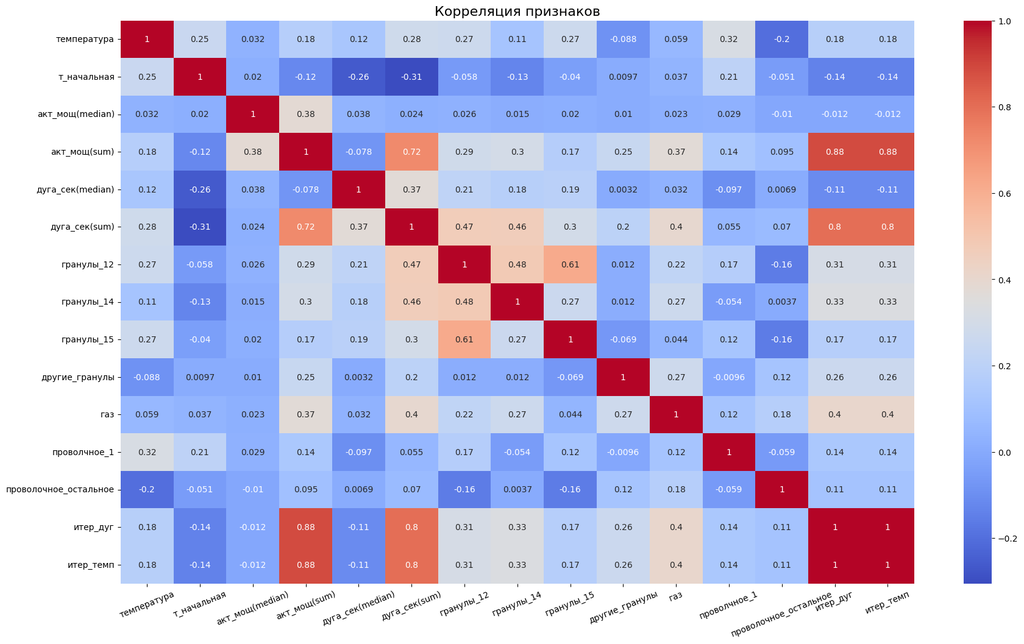

```python
plt.figure(figsize=(21, 12))
fig = sns.heatmap(data.corr(), cmap='coolwarm', annot=True)
plt.title('Корреляция признаков', fontsize=16)
plt.setp(fig.get_xticklabels(), rotation=22)
plt.show();
```

'итер_дуг' и 'итер_темп' сильно коррелируют, что и понятно из анализа выше

## Подготовка признаков

### Вспомогательный блок

Определим функцию для разделение выборки на обучающие признаки и целевой

```python
def split_into_signs(sign):
    features_train = sign.drop('температура', axis=1)
    target_train = sign['температура']
    return features_train, target_train
```

Определим функцию для контроля значений

```python
def check_val_signs():
    dict_signs = {'features_train':train, 'features_test':test}
    print('Количество объектов в выборках')
    for key, val in dict_signs.items():
        print(f'{key}: {val.shape[0]} {val.shape[0]/data.shape[0] :.2f}')
```

### Разделение на выбороки

Разделим набор данных на выборки, ориентируясь на критерий.

```python
train, test = train_test_split(data, random_state=280823, test_size=.25)
```

### Изучение и обработка выборок

Для нас важно, чтобы тестовый набор данных остался как есть, когда обучающий можно обработать от искажений.

#### train

```python
train.head()
```

| key | температура | т_начальная | акт_мощ(median) | акт_мощ(sum) | дуга_сек(median) | дуга_сек(sum) | гранулы_12 | гранулы_14 | гранулы_15 | другие_гранулы | газ | проволчное_1 | проволочное_остальное | итер_дуг | итер_темп |
| --- | --- | --- | --- | --- | --- | --- | --- | --- | --- | --- | --- | --- | --- | --- | --- |
| 77 | 1604.0 | 1605.0 | 0.674262 | 4.079181 | 138.5 | 1216.0 | 408.0 | 215.0 | 203.0 | 271.0 | 11.024942 | 110.292000 | 45.135998 | 6.0 | 7.0 |
| 2378 | 1589.0 | 1580.0 | 0.565128 | 4.516180 | 107.5 | 1056.0 | 125.0 | 179.0 | 104.0 | 66.0 | 11.743407 | 50.974560 | 75.400001 | 8.0 | 9.0 |
| 530 | 1581.0 | 1596.0 | 0.412150 | 0.412150 | 241.0 | 241.0 | 106.0 | 255.0 | 0.0 | 0.0 | 4.247358 | 0.000000 | 22.107281 | 1.0 | 2.0 |
| 1857 | 1585.0 | 1585.0 | 0.555978 | 1.738832 | 187.0 | 614.0 | 0.0 | 199.0 | 0.0 | 41.0 | 6.080227 | 101.649598 | 0.000000 | 3.0 | 4.0 |
| 135 | 1581.0 | 1579.0 | 0.539665 | 3.606951 | 160.5 | 1023.0 | 512.0 | 254.0 | 201.0 | 397.0 | 7.017192 | 124.225914 | 51.205441 | 6.0 | 7.0 |

```python
train_shape = train.shape[0]
```

Обрабтаем некоторые столбцы с выбросами:

- температура;
- газ;
- акт_мощ(median).

Дополнительно изучим столбец дуга_сек(median). Для удаления выбросов используем полученные ранее границы усов.

##### температура

```python
print('Температурные усы', moustache_dtn)
```

```
Температурные усы {'температура': [1552.0, 1627.0]}
```

```python
left_moust = moustache_dtn['температура'][0]
right_moust = moustache_dtn['температура'][1]
train = train.query('@left_moust <= температура <= @right_moust')
```

```python
train.shape[0]
```

```
1736
```

##### газ

```python
print('Газовые усы', moustache_dgn)
```

```
Газовые усы {'газ': [0.0083985291, 23.8112788026]}
```

```python
left_moust = moustache_dgn['газ'][0]
right_moust = moustache_dgn['газ'][1]
train = train.query('@left_moust <= газ <= @right_moust')
```

```python
train.shape[0]
```

```
1655
```

##### акт_мощ(median)

```python
print('Мощные усы', moustache_dan)
```

```
Мощные усы {'Активная мощность': [0.22312, 1.373621], 'Реактивная мощность': [0.153777, 1.014739]}
```

```python
left_moust = moustache_dan['Активная мощность'][0]
right_moust = moustache_dan['Активная мощность'][1]
train = train.query('@left_moust <= `акт_мощ(median)` <= @right_moust')
```

```python
print('Данных удалено(%):',round(1 - train.shape[0]/train_shape,3))
```

```
Данных удалено(%): 0.052
```

```python
train.shape[0]
```

```
1655
```

##### дуга_сек(median)

Посмотрим что представляют данные

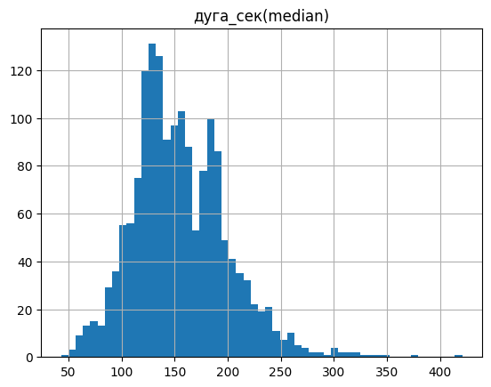

```python
train.hist('дуга_сек(median)', bins=55);
```

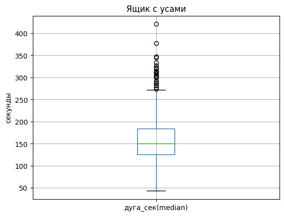

```python
b = train.boxplot('дуга_сек(median)', return_type='dict')

plt.ylabel('секунды')
plt.title('Ящик с усами');

moustache_asm = {}
moustache_asm['секунды'] = [item.get_ydata()[1] for item in b['whiskers']]
```

```python
print('Усы времени', moustache_asm)
```

```
Усы времени {'секунды': [43.0, 272.0]}
```

```python
left_moust = moustache_asm['секунды'][0]
right_moust = moustache_asm['секунды'][1]
train = train.query('@left_moust <= `дуга_сек(median)` <= @right_moust')
```

```python
print('Данных удалено(%):',round(1 - train.shape[0]/train_shape,3))
```

```
Данных удалено(%): 0.065
```

```python
train.shape[0]
```

```
1633
```

##### Вывод

*Предобработка завершена*

### Обучающий и целевой

Определим обучающий и целевой признак

```python
features_train, target_train = split_into_signs(train)
features_test, target_test = split_into_signs(test)
```

```python
check_val_signs()
```

```
Количество объектов в выборках
features_train: 1633 0.70
features_test: 583 0.25
```